# **First experimental evidence for active farming in ambrosia beetles and strong heredity of garden microbiomes** - Fungal Analysis

test with subset 2

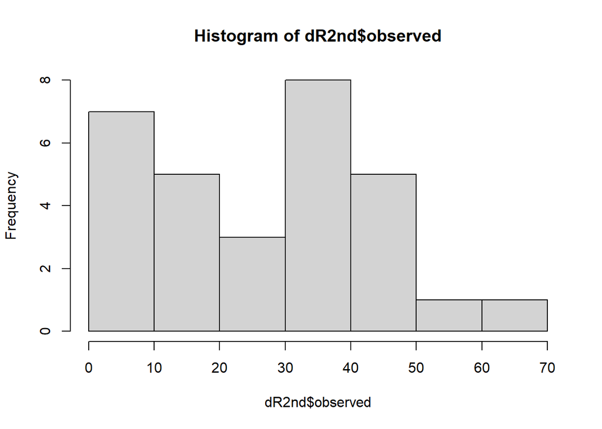

```r
hist(dR2nd$observed)
```

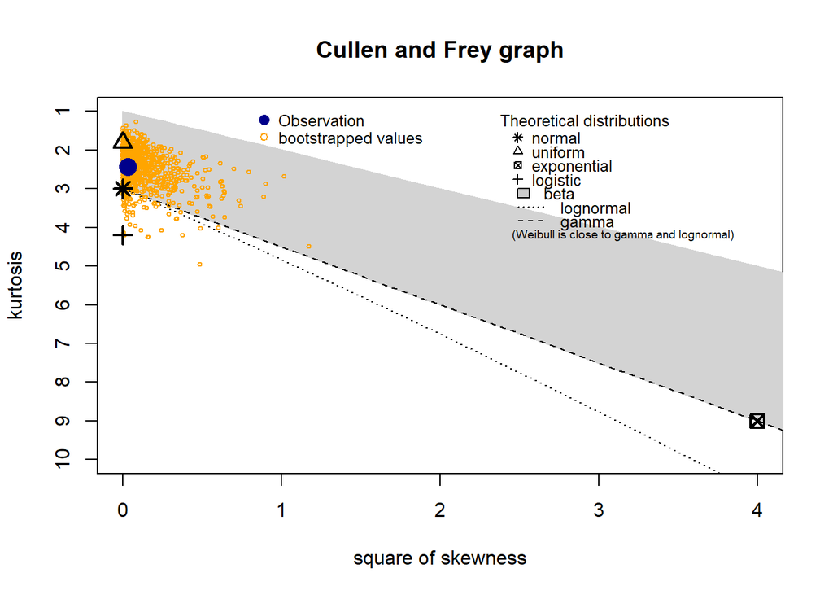

```
## summary statistics
## ------
## min:  1   max:  62
## median:  29
## mean:  27.46667
## estimated sd:  16.49605
## estimated skewness:  0.1784444
## estimated kurtosis:  2.434842
```

```r
descdist(dR2nd$observed, boot = 1000)
```

```r
ob2 <- glm(observed ~ Treatment + Linage, data = dR2nd)
Anova(ob2, type = "II")
```

```
## Analysis of Deviance Table (Type II tests)
##
## Response: observed
##           LR Chisq Df Pr(>Chisq)
## Treatment   3.1731  1    0.07486 .
## Linage     18.8360  9    0.02662 *
## ---
## Signif. codes:  0 '***' 0.001 '**' 0.01 '*' 0.05 '.' 0.1 ' ' 1
```

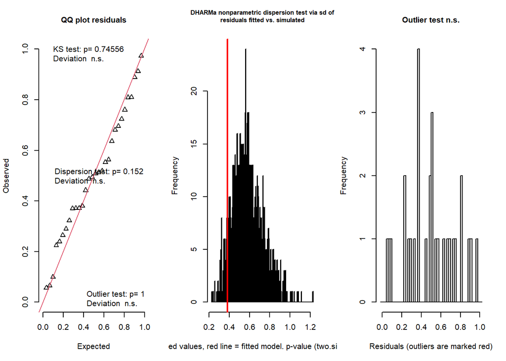

```
## $uniformity
##
##  One-sample Kolmogorov-Smirnov test
##
## data:  simulationOutput$scaledResiduals
## D = 0.124, p-value = 0.7456
## alternative hypothesis: two-sided
##
##
## $dispersion
##
##  DHARMa nonparametric dispersion test via sd of residuals fitted vs.
##  simulated
##
## data:  simulationOutput
## dispersion = 0.65369, p-value = 0.152
## alternative hypothesis: two.sided
##
##
## $outliers
##
##  DHARMa outlier test based on exact binomial test with approximate
##  expectations
##
## data:  simulationOutput
## outliers at both margin(s) = 0, observations = 30, p-value = 1
## alternative hypothesis: true probability of success is not equal to 0.001998002
## 95 percent confidence interval:
##  0.0000000 0.1157033
## sample estimates:
## frequency of outliers (expected: 0.001998001998002 )
##                                                    0
```

```
## $uniformity
##
##  One-sample Kolmogorov-Smirnov test
##
## data:  simulationOutput$scaledResiduals
## D = 0.124, p-value = 0.7456
## alternative hypothesis: two-sided
##
##
## $dispersion
##
##  DHARMa nonparametric dispersion test via sd of residuals fitted vs.
##  simulated
##
## data:  simulationOutput
## dispersion = 0.65369, p-value = 0.152
## alternative hypothesis: two.sided
##
##
## $outliers
##
##  DHARMa outlier test based on exact binomial test with approximate
##  expectations
##
## data:  simulationOutput
## outliers at both margin(s) = 0, observations = 30, p-value = 1
## alternative hypothesis: true probability of success is not equal to 0.001998002
## 95 percent confidence interval:
##  0.0000000 0.1157033
## sample estimates:
## frequency of outliers (expected: 0.001998001998002 )
##                                                    0
```

```r
res_ob2 <- simulateResiduals(ob2, n = 1000)
testResiduals(res_ob2)
```

## **Beta Diversity**

**Beta diversity and microbiome divergence**

Beta diversity quantifies dissimilarity in community composition between samples. Dissimilarity can be also quantified by distance or divergence. These measures have a broad use in statistical data analysis.

```r
rel.CR <- CR %>%
  transform_sample_counts(function(x) {x/sum(x)} )

rel.R2nd <- R2nd %>%
  transform_sample_counts(function(x) {x/sum(x)} )
```

#### relative Abundance plots

agglomerate data to Species level, transform to rel. abundance, melt long format and sort data frame alph. by Species

```r
Fungi_Species1 <- CR %>%
  tax_glom(taxrank = "Species") %>%
  transform_sample_counts(function(x) {x/sum(x)} ) %>%
  psmelt() %>%
  arrange(Species)

Fungi_Species2 <- R2nd %>%
  tax_glom(taxrank = "Species") %>%
  transform_sample_counts(function(x) {x/sum(x)} ) %>%
  psmelt() %>%
  arrange(Species)
```

find the mean and standard deviation by Species

```r
rem <- subset(Fungi_Species1, Treatment == "removal")
mean.rem <- tapply(rem$Abundance, rem$Species, mean)
mean.rem
```

```
##             Acremonium_biseptum                  Acremonium_spc
##                    4.822926e-02                    1.825963e-04
##              Ascomycota_spc_spc         Aspergillus_costiformis
##                    1.921889e-03                    2.792152e-05
##               Chaetomiaceae_spc             Chaetomium_globosum
##                    1.527656e-03                    5.751256e-01
##                  Chaetomium_spc            Diatrypella_vulgaris
##                    5.217036e-03                    7.370756e-05
##                  Eurotiales_spc              Eurotiomycetes_spc
##                    1.585447e-04                    6.946107e-05
##                 Hypocreales_spc            Ophiostomataceae_spc
##                    3.086386e-04                    1.346598e-04
##             Ophiostomatales_spc                Paecilomyces_spc
##                    1.862119e-04                    4.264759e-05
##             Penicillium_commune                 Penicillium_spc
##                    7.113496e-03                    2.412351e-03
##            Raffaelea_canadensis                   Raffaelea_spc
##                    3.755341e-02                    1.845842e-03
##             Raffaelea_sulphurea                 Sordariales_spc
##                    3.076030e-01                    3.200399e-04
##             Sordariomycetes_spc           Sporothrix_stenoceras
##                    8.133021e-03                    1.045215e-05
##           Talaromyces_rugulosus              Thermoascaceae_spc
##                    1.273286e-03                    8.691522e-05
## Xenopolyscytalum_sp._I12F_02273                  Xylariales_spc
##                    3.227091e-04                    1.196866e-04
```

```r
SD.rem <- tapply(rem$Abundance, rem$Species, sd)
SD.rem
```

```
##             Acremonium_biseptum                  Acremonium_spc
##                    2.129341e-01                    7.380513e-04
##              Ascomycota_spc_spc         Aspergillus_costiformis
##                    7.016012e-03                    1.248688e-04
##               Chaetomiaceae_spc             Chaetomium_globosum
##                    2.777907e-03                    3.863477e-01
##                  Chaetomium_spc            Diatrypella_vulgaris
##                    5.606403e-03                    3.109255e-04
##                  Eurotiales_spc              Eurotiomycetes_spc
##                    5.080569e-04                    1.680653e-04
##                 Hypocreales_spc            Ophiostomataceae_spc
##                    1.303065e-03                    3.373166e-04
##             Ophiostomatales_spc                Paecilomyces_spc
##                    3.095223e-04                    1.685520e-04
##             Penicillium_commune                 Penicillium_spc
##                    3.178475e-02                    1.076897e-02
##            Raffaelea_canadensis                   Raffaelea_spc
##                    5.985818e-02                    4.362601e-03
##             Raffaelea_sulphurea                 Sordariales_spc
##                    3.306086e-01                    4.252054e-04
##             Sordariomycetes_spc           Sporothrix_stenoceras
##                    8.708500e-03                    3.295761e-05
##           Talaromyces_rugulosus              Thermoascaceae_spc
##                    4.413233e-03                    2.700954e-04
## Xenopolyscytalum_sp._I12F_02273                  Xylariales_spc
##                    7.445484e-04                    5.352549e-04
```

```r
sec <- subset(Fungi_Species2, Treatment == "2nd-foundation")
mean.sec <- tapply(sec$Abundance, sec$Species, mean)
mean.sec
```

```
##             Acremonium_biseptum                  Acremonium_spc
##                    0.0236606934                    0.0039535863
##              Ascomycota_spc_spc         Aspergillus_costiformis
##                    0.0032163024                    0.0000000000
##               Chaetomiaceae_spc             Chaetomium_globosum
##                    0.0073566780                    0.5073275038
##                  Chaetomium_spc            Diatrypella_vulgaris
##                    0.0085913959                    0.0000000000
##                  Eurotiales_spc              Eurotiomycetes_spc
##                    0.0007557944                    0.0000877943
##                 Hypocreales_spc            Ophiostomataceae_spc
##                    0.0032611238                    0.0005139207
##             Ophiostomatales_spc                Paecilomyces_spc
##                    0.0007235568                    0.0000000000
##             Penicillium_commune                 Penicillium_spc
##                    0.0316822915                    0.0072273551
##            Raffaelea_canadensis                   Raffaelea_spc
##                    0.1175589366                    0.0072412047
##             Raffaelea_sulphurea                 Sordariales_spc
##                    0.2531221210                    0.0016430442
##             Sordariomycetes_spc           Sporothrix_stenoceras
##                    0.0207058085                    0.0000000000
##           Talaromyces_rugulosus              Thermoascaceae_spc
##                    0.0000000000                    0.0000000000
## Xenopolyscytalum_sp._I12F_02273                  Xylariales_spc
##                    0.0000000000                    0.0013708885
```

```r
SD.sec <- tapply(sec$Abundance, sec$Species, sd)
SD.sec
```

```
##             Acremonium_biseptum                  Acremonium_spc
##                    0.0784736423                    0.0131125623
##              Ascomycota_spc_spc         Aspergillus_costiformis
##                    0.0089808210                    0.0000000000
##               Chaetomiaceae_spc             Chaetomium_globosum
##                    0.0091540276                    0.3533535207
##                  Chaetomium_spc            Diatrypella_vulgaris
##                    0.0099731689                    0.0000000000
##                  Eurotiales_spc              Eurotiomycetes_spc
##                    0.0025066865                    0.0002911808
##                 Hypocreales_spc            Ophiostomataceae_spc
##                    0.0108159242                    0.0013543344
##             Ophiostomatales_spc                Paecilomyces_spc
##                    0.0011593941                    0.0000000000
##             Penicillium_commune                 Penicillium_spc
##                    0.1050782734                    0.0239371110
##            Raffaelea_canadensis                   Raffaelea_spc
##                    0.1306026315                    0.0142054109
##             Raffaelea_sulphurea                 Sordariales_spc
##                    0.2771804794                    0.0029798185
##             Sordariomycetes_spc           Sporothrix_stenoceras
##                    0.0243502551                    0.0000000000
##           Talaromyces_rugulosus              Thermoascaceae_spc
##                    0.0000000000                    0.0000000000
## Xenopolyscytalum_sp._I12F_02273                  Xylariales_spc
##                    0.0000000000                    0.0045467228
```

```r
control <- subset(Fungi_Species1, Treatment == "control")
mean.control <- tapply(control$Abundance, control$Species, mean)
mean.control
```

```
##             Acremonium_biseptum                  Acremonium_spc
##                    2.018503e-03                    6.968641e-06
##              Ascomycota_spc_spc         Aspergillus_costiformis
##                    6.965760e-05                    8.988316e-05
##               Chaetomiaceae_spc             Chaetomium_globosum
##                    4.590560e-04                    3.796378e-01
##                  Chaetomium_spc            Diatrypella_vulgaris
##                    2.400139e-03                    0.000000e+00
##                  Eurotiales_spc              Eurotiomycetes_spc
##                    0.000000e+00                    0.000000e+00
##                 Hypocreales_spc            Ophiostomataceae_spc
##                    0.000000e+00                    2.804989e-04
##             Ophiostomatales_spc                Paecilomyces_spc
##                    2.988574e-04                    0.000000e+00
##             Penicillium_commune                 Penicillium_spc
##                    1.328225e-05                    0.000000e+00
##            Raffaelea_canadensis                   Raffaelea_spc
##                    1.104248e-01                    3.631699e-03
##             Raffaelea_sulphurea                 Sordariales_spc
##                    4.948844e-01                    1.094521e-04
##             Sordariomycetes_spc           Sporothrix_stenoceras
##                    5.383031e-03                    0.000000e+00
##           Talaromyces_rugulosus              Thermoascaceae_spc
##                    2.899075e-04                    0.000000e+00
## Xenopolyscytalum_sp._I12F_02273                  Xylariales_spc
##                    2.028727e-06                    0.000000e+00
```

```r
SD.control <- tapply(control$Abundance, control$Species, sd)
SD.control
```

```
##             Acremonium_biseptum                  Acremonium_spc
##                    9.027020e-03                    3.116471e-05
##              Ascomycota_spc_spc         Aspergillus_costiformis
##                    1.752356e-04                    2.666390e-04
##               Chaetomiaceae_spc             Chaetomium_globosum
##                    7.011706e-04                    2.980927e-01
##                  Chaetomium_spc            Diatrypella_vulgaris
##                    2.929313e-03                    0.000000e+00
##                  Eurotiales_spc              Eurotiomycetes_spc
##                    0.000000e+00                    0.000000e+00
##                 Hypocreales_spc            Ophiostomataceae_spc
##                    0.000000e+00                    1.103085e-03
##             Ophiostomatales_spc                Paecilomyces_spc
##                    8.186757e-04                    0.000000e+00
##             Penicillium_commune                 Penicillium_spc
##                    3.777937e-05                    0.000000e+00
##            Raffaelea_canadensis                   Raffaelea_spc
##                    1.134036e-01                    5.389495e-03
##             Raffaelea_sulphurea                 Sordariales_spc
##                    2.584721e-01                    2.370017e-04
##             Sordariomycetes_spc           Sporothrix_stenoceras
##                    9.740509e-03                    0.000000e+00
##           Talaromyces_rugulosus              Thermoascaceae_spc
##                    1.026525e-03                    0.000000e+00
## Xenopolyscytalum_sp._I12F_02273                  Xylariales_spc
##                    9.072742e-06                    0.000000e+00
```

edit object for plotting

```r
#control vs. removal
Fungi_Species1$Species<-as.character(Fungi_Species1$Species)
Fungi_Species1$Species[Fungi_Species1$Abundance<0.05]<-"Others"
Fungi_Species1$Class<-as.character(Fungi_Species1$Class)
Fungi_Species1$Class[Fungi_Species1$Abundance<0.05]<-"Others"
Fungi_Species1$Species<-factor(Fungi_Species1$Species)
Fungi_Species1<-droplevels(Fungi_Species1)
Fungi_Species1$Treatment<-factor(Fungi_Species1$Treatment,levels=c("control", "removal"))
Fungi_Species1$Species <- factor(Fungi_Species1$Species, levels = c("Others", "Sordariomycetes_spc", "Penicillium_commune", "Penicillium_spc", "Acremonium_biseptum", "Chaetomium_globosum","Raffaelea_canadensis", "Raffaelea_sulphurea"), labels = c("Others (< 0.5%)", "Sordariomycetes sp.", "Penicillium commune", "Penicillium sp.","Acremonium biseptum", "Chaetomium globosum", "Raffaelea canadensis", "Raffaelea sulphurea"))

#removal vs. 2^nd^ attempt
Fungi_Species2$Species<-as.character(Fungi_Species2$Species)
Fungi_Species2$Species[Fungi_Species2$Abundance<0.05]<-"Others"
Fungi_Species2$Class<-as.character(Fungi_Species2$Class)
Fungi_Species2$Class[Fungi_Species2$Abundance<0.05]<-"Others"
Fungi_Species2$Species<-factor(Fungi_Species2$Species)
Fungi_Species2<-droplevels(Fungi_Species2)
Fungi_Species2$Treatment<-factor(Fungi_Species2$Treatment,levels=c("removal", "2nd-foundation"))
Fungi_Species2$Species<-factor(Fungi_Species2$Species,levels=levels(Fungi_Species2$Species))
Fungi_Species2$Species <- factor(Fungi_Species2$Species, levels = c("Others", "Sordariomycetes_spc", "Penicillium_spc", "Penicillium_commune", "Acremonium_biseptum", "Chaetomium_globosum", "Raffaelea_canadensis", "Raffaelea_sulphurea"), labels = c("Others (< 0.5%)", "Sordariomycetes sp.", "Penicillium sp.", "Penicillium commune", "Acremonium biseptum", "Chaetomium globosum", "Raffaelea canadensis", "Raffaelea sulphurea"))
```

define plot colors

```r
Plot_colors_s <- c("grey87", "forestgreen", "peachpuff3", "lightskyblue","goldenrod3", "gold")

Plot_colors_s2 <- c("lightskyblue", "gold", "peachpuff3", "brown1", "chocolate1", "forestgreen", "grey87")

Plot_colors_s3 <- c("grey87", "bisque", "darkgreen", "forestgreen", "peachpuff3", "lightskyblue", "goldenrod3", "gold")

Plot_colors_s4 <- c("lightskyblue", "gold", "brown1", "chocolate1", "grey87")

Plot_colors_s5 <- c("lightskyblue",  "coral4", "gold", "peachpuff3", "brown1", "chocolate1", "forestgreen", "grey87")
```

##### plot control vs. removal

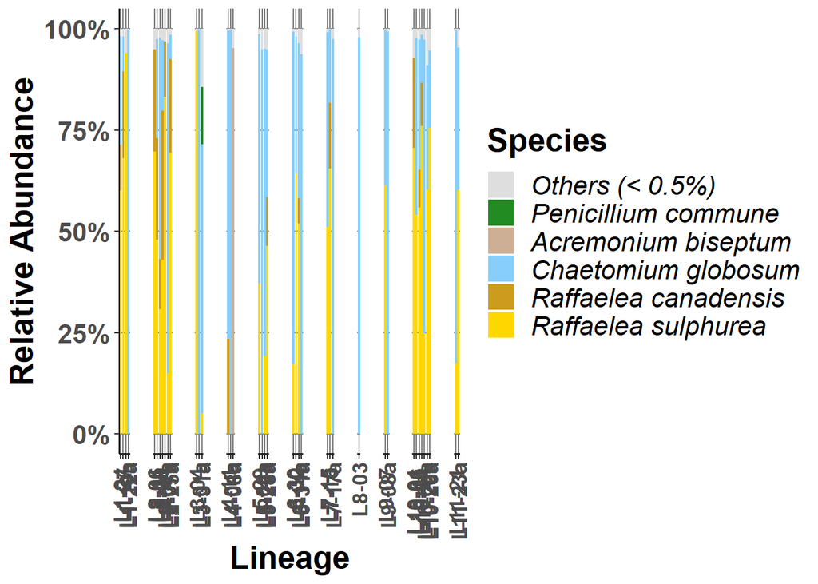

```r
Fun2 <- Fungi_Species1
Fun2$Sample <- factor(Fun2$Sample, levels = c("B0-24", "B0-27", "B0-19a", "B0-22a", "B15-06", "B15-11", "B15-20", "B15-24", "B15-01a", "B15-07a", "B15-25a", "B16-04", "B16-01a", "B16-31a", "B20-11", "B20-04a", "B20-08a", "B24-29", "B24-02a", "B24-26a", "B24-28a", "B36-30", "B36-32", "B36-14a", "B36-31a", "B39-15", "B39-16", "B39-17a", "B46-03", "B7-07", "B7-08a", "B10-01", "B10-06", "B10-18", "B10-24", "B10-09a", "B10-25a", "B10-26a", "B23-21", "B23-23a"), labels = c("L1-24", "L1-27", "L1-19a", "L1-22a", "L2-06", "L2-11", "L2-20", "L2-24", "L2-01a", "L2-07a", "L2-25a", "L3-04", "L3-01a", "L3-31a", "L4-11", "L4-04a", "L4-08a", "L5-29", "L5-02a", "L5-26a", "L5-28a", "L6-30", "L6-32", "L6-14a", "L6-31a", "L7-15", "L7-16", "L7-17a", "L8-03", "L9-07", "L9-08a", "L10-01", "L10-06", "L10-18", "L10-24", "L10-09a", "L10-25a", "L10-26a", "L11-21", "L11-23a"))
Fun2$Linage <- factor(Fun2$Linage, levels = c("B0", "B15", "B16", "B20", "B24", "B36", "B39", "B46", "B7", "B10", "B23"))

Fungi_Species_plot2 <- ggplot(Fun2, aes(x = Sample, y = Abundance, fill = Species)) +
  geom_bar(stat = "identity", color = NA,  position="fill") +
  scale_fill_manual(values = Plot_colors_s, name = "Species")

relAb_fun<-Fungi_Species_plot2 +
  facet_grid(~ Linage, scales = "free_x", space = "free_x")+
  theme(plot.title = element_text(size = 20, face = "bold")) +
  theme_classic()+           #gets rid of background
  theme(panel.grid.major = element_line(colour = "grey50"))+
  labs(x="Lineage", y="Relative Abundance")+
  scale_y_continuous(labels=percent_format())+
  theme(axis.text.x=element_text(size = 13, angle = 90, vjust = 0.5))+
  theme(text = element_text(size=20, face = "bold"))+
  theme(legend.title = element_text(size = 20), legend.text = element_text(size = 16))+
  theme(legend.text = element_text(face = "italic"))+
  theme(strip.text.x = element_blank())

relAb_fun <- relAb_fun + theme(panel.spacing.x = unit(0.5, "cm"))

relAb_fun
```

plot relative abundance with strains

```r
CR_melt <- CR %>%
  transform_sample_counts(function(x) {x/sum(x)} ) %>%
  psmelt() %>%
  arrange(Species)
```

```r
CR_melt$best_hit<-as.character(CR_melt$best_hit)
CR_melt$best_hit[CR_melt$Abundance<0.05]<-"Others"

CR_OTU <- CR_melt
CR_OTU$Linage <- factor(CR_OTU$Linage, levels = c("B0", "B15", "B16", "B20", "B24", "B36", "B39", "B46", "B7", "B10", "B23"), labels = c("L1", "L2", "L3", "L4", "L5", "L6", "L7", "L8", "L9", "L10", "L11"))
CR_OTU$best_hit <- factor(CR_OTU$best_hit, labels = c("zOTU1: Chaetomium globosum", "zOTU2: Raffaelea sulphurea", "zOTU3: Acremonium biseptum", "zOTU4: Raffaelea canadensis", "zOTU5: Raffaelea canadensis", "zOTU8:Penicillium commune",  "Others (< 0.5%)"))

control_OTU <- subset(CR_OTU, Treatment == "control")

Fungi_OTU_plot <- ggplot(CR_OTU, aes(x = Linage, y = Abundance, fill = best_hit)) +
  geom_bar(stat = "identity", color = NA,  position="fill") +
  scale_fill_manual(values = Plot_colors_s2, name = "Fungal Strains")

relAb_funOTU<-Fungi_OTU_plot +
  theme(plot.title = element_text(size = 20, face = "bold")) +
  theme_classic()+           #gets rid of background
  theme(panel.grid.major = element_line(colour = "grey50"))+
  labs(x="Lineage", y="Relative Abundance")+
  scale_y_continuous(labels=percent_format())+
  theme(axis.text.x=element_text(size = 13, angle = 90, vjust = 0.5))+
  theme(text = element_text(size=20, face = "bold"))+
  theme(legend.title = element_text(size = 20), legend.text = element_text(size = 16))+
  theme(legend.text = element_text(face = "italic"))+
  theme(strip.text.x = element_blank())

relAb_fun_OTU <- relAb_funOTU + theme(panel.spacing.x = unit(0.5, "cm"))

Fungi_OTU_plot2 <- ggplot(control_OTU, aes(x = Linage, y = Abundance, fill = best_hit)) +
  geom_bar(stat = "identity", color = NA,  position="fill") +
  scale_fill_manual(values = Plot_colors_s4, name = "Fungal Strains")

relAb_funOTU2<-Fungi_OTU_plot2 +
  theme(plot.title = element_text(size = 20, face = "bold")) +
  theme_classic()+           #gets rid of background
  theme(panel.grid.major = element_line(colour = "grey50"))+
  labs(x="Lineage", y="Relative Abundance")+
  scale_y_continuous(labels=percent_format())+
  theme(axis.text.x=element_text(size = 13, angle = 90, vjust = 0.5))+
  theme(text = element_text(size=20, face = "bold"))+
  theme(legend.title = element_text(size = 20), legend.text = element_text(size = 16))+
  theme(legend.text = element_text(face = "italic"))+
  theme(strip.text.x = element_blank())

relAb_fun_OTU2 <- relAb_funOTU2 + theme(panel.spacing.x = unit(0.5, "cm"))
```

#### plot removal vs. 2<sup>nd</sup>-attempt

[figure not shown]

```r
Fun3 <- Fungi_Species2
Fun3$Nest <- factor(Fun3$Nest, levels = c("B0-19", "B0-22", "B15-01", "B15-07", "B15-25", "B16-01", "B16-31", "B20-04", "B20-08", "B24-02", "B24-26", "B24-28", "B36-14", "B36-31", "B39-17", "B7-08", "B10-09", "B10-25", "B10-26", "B23-23"))
Fun3$Sample <- factor(Fun3$Sample, levels = c("B0-19a", "B0-19b", "B0-22a", "B0-22b", "B15-01a", "B15-01b", "B15-07a", "B15-07b", "B15-25a", "B15-25b", "B16-01a", "B16-31a", "B16-31b", "B20-04a", "B20-08a", "B20-08b", "B24-02a", "B24-26a", "B24-26b", "B24-28a", "B36-14a", "B36-14b", "B36-31a", "B39-17a", "B7-08a", "B10-09a", "B10-09b", "B10-25a", "B10-25b", "B10-26a", "B23-23a"), labels = c("L1-19a", "L1-19b", "L1-22a", "L1-22b", "L2-01a", "L2-01b", "L2-07a", "L2-07b", "L2-25a", "L2-25b", "L3-01a", "L3-31a", "L3-31b", "L4-04a", "L4-08a", "L4-08b", "L5-02a", "L5-26a", "L5-26b", "L5-28a", "L6-14a", "L6-14b", "L6-31a", "L7-17a", "L9-08a", "L10-09a", "L10-09b", "L10-25a", "L10-25b", "L10-26a", "L11-23a"))

Fungi_Species2_plot2 <- ggplot(Fun3, aes(x = Sample, y = Abundance, fill = Species)) +
  geom_bar(stat = "identity", color = NA,  position="fill") +
  scale_fill_manual(values = Plot_colors_s3, name = "Species")

g4<-Fungi_Species2_plot2 +
  facet_grid(~ Nest, scales = "free_x", space = "free_x")+
  theme(plot.title = element_text(size = 20, face = "bold")) +
  theme_classic()+           #gets rid of background
  theme(panel.grid.major = element_line(colour = "grey50"))+
  labs(x="Nest", y="Relative Abundance")+
  scale_y_continuous(labels=percent_format())+
  theme(axis.text.x=element_text(size = 13, angle = 90, vjust = 0.5))+
  theme(text = element_text(size=20, face = "bold"))+
  theme(legend.title = element_text(size = 20), legend.text = element_text(size = 16))+
  theme(legend.text = element_text(face = "italic"))+
  theme(strip.text.x = element_blank())

relAb_fun2 <- g4 + theme(panel.spacing.x = unit(0.5, "cm"))

relAb_fun2
```

plot relative abundance with strains

```r
R2nd_melt <- R2nd %>%
  transform_sample_counts(function(x) {x/sum(x)} ) %>%
  psmelt() %>%
  arrange(Species)
```

```r
R2nd_melt$best_hit<-as.character(R2nd_melt$best_hit)
R2nd_melt$best_hit[R2nd_melt$Abundance<0.05]<-"Others"

R2nd_OTU <- R2nd_melt
R2nd_OTU$Nest <- factor(R2nd_OTU$Nest, levels = c("B0-19", "B0-22", "B15-01", "B15-07", "B15-25", "B16-01", "B16-31", "B20-04", "B20-08", "B24-02", "B24-26", "B24-28", "B36-14", "B36-31", "B39-17", "B7-08", "B10-09", "B10-25", "B10-26", "B23-23"))
R2nd_OTU$Sample <- factor(R2nd_OTU$Sample, levels = c("B0-19a", "B0-19b", "B0-22a", "B0-22b", "B15-01a", "B15-01b", "B15-07a", "B15-07b", "B15-25a", "B15-25b", "B16-01a", "B16-31a", "B16-31b", "B20-04a", "B20-08a", "B20-08b", "B24-02a", "B24-26a", "B24-26b", "B24-28a", "B36-14a", "B36-14b", "B36-31a", "B39-17a", "B7-08a", "B10-09a", "B10-09b", "B10-25a", "B10-25b", "B10-26a", "B23-23a"), labels = c("L1-19a", "L1-19b", "L1-22a", "L1-22b", "L2-01a", "L2-01b", "L2-07a", "L2-07b", "L2-25a", "L2-25b", "L3-01a", "L3-31a", "L3-31b", "L4-04a", "L4-08a", "L4-08b", "L5-02a", "L5-26a", "L5-26b", "L5-28a", "L6-14a", "L6-14b", "L6-31a", "L7-17a", "L9-08a", "L10-09a", "L10-09b", "L10-25a", "L10-25b", "L10-26a", "L11-23a"))
R2nd_OTU$best_hit <- factor(R2nd_OTU$best_hit, labels = c("zOTU1: Chaetomium globosum", "zOTU11: Raffaelea canadensis", "zOTU2: Raffaelea sulphurea", "zOTU3: Acremonium biseptum", "zOTU4: Raffaelea canadensis", "zOTU5: Raffaelea canadensis", "zOTU8:Penicillium commune",  "Others (< 0.5%)"))

Fungi_OTU_plot <- ggplot(R2nd_OTU, aes(x = Sample, y = Abundance, fill = best_hit)) +
  geom_bar(stat = "identity", color = NA,  position="fill") +
  scale_fill_manual(values = Plot_colors_s5, name = "Fungal Strains")

relAb_funOTU3<-Fungi_OTU_plot +
  facet_grid(~ Nest, scales = "free_x", space = "free_x")+
  theme(plot.title = element_text(size = 20, face = "bold")) +
  theme_classic()+           #gets rid of background
  theme(panel.grid.major = element_line(colour = "grey50"))+
  labs(x="Lineage", y="Relative Abundance")+
  scale_y_continuous(labels=percent_format())+
  theme(axis.text.x=element_text(size = 13, angle = 90, vjust = 0.5))+
  theme(text = element_text(size=20, face = "bold"))+
  theme(legend.title = element_text(size = 20), legend.text = element_text(size = 16))+
  theme(legend.text = element_text(face = "italic"))+
  theme(strip.text.x = element_blank())

relAb_fun_OTU3 <- relAb_funOTU3 + theme(panel.spacing.x = unit(0.5, "cm"))
```

### **Microbiome composition**

##### Composition heatmaps

**plot control vs. removal (>5% abundance)**

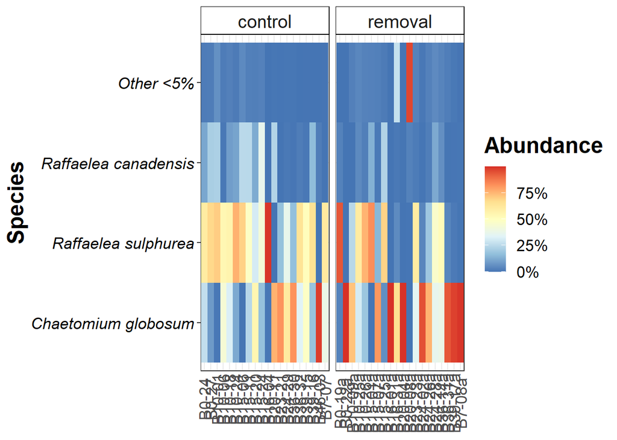

```r
pseq <- aggregate_rare(rel.CR, level = "Species", detection = 5/100, prevalence = 10/100)

pseqh <- pseq %>%
  psmelt()

pseqh$Treatment<-factor(pseqh$Treatment,levels=c("control", "removal"))
pseqh$Species<-factor(pseqh$Species,levels=c("Chaetomium_globosum", "Raffaelea_sulphurea", "Raffaelea_canadensis", "Other"), labels = c("Chaetomium globosum", "Raffaelea sulphurea", "Raffaelea canadensis", "Other <5%"))

p.heat <- ggplot(pseqh, aes(x = Sample, y = Species)) + geom_tile(aes(fill = Abundance))

# Change color
p.heat <- p.heat + scale_fill_distiller("Abundance", palette = "RdYlBu", labels = scales::percent) + theme_bw()

# Make bacterial names italics
p.heat <- p.heat + theme(axis.text.y = element_text(colour = 'black',
                                                    size = 10,
                                                    face = 'italic'))
# Make separate samples based on main variable
p.heat <- p.heat + facet_grid(~Treatment,
                              scales = "free") + rremove("x.text")

#Clean the x-axis
p.heat <- p.heat + theme(axis.title.x=element_blank(),
                     axis.text.x=element_blank(),
                     axis.ticks.x=element_blank())

# Clean the facet label box
p.heat <- p.heat + theme(legend.key = element_blank(),
                     strip.background = element_rect(colour="black", fill="white"))+
                      theme(strip.text = element_text(size = 15))

p.heat + theme(axis.text.x=element_text(angle = 90, size = 13))+
  theme(axis.title.y = element_text(size = 18, face = "bold"), axis.title.x = element_blank())+
  theme(axis.text.y = element_text(size = 13, face = "italic"))+
  theme(legend.text = element_text(size = 13))+
  theme(legend.title = element_text(size = 18, face = "bold"))
```

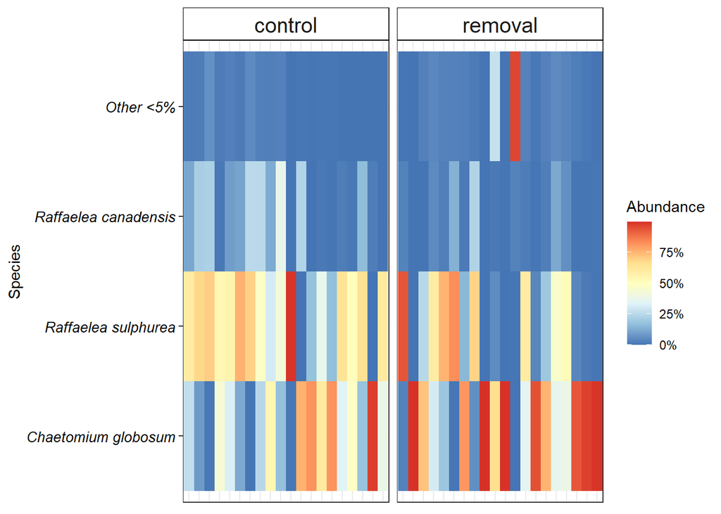

```r
p.heat
```

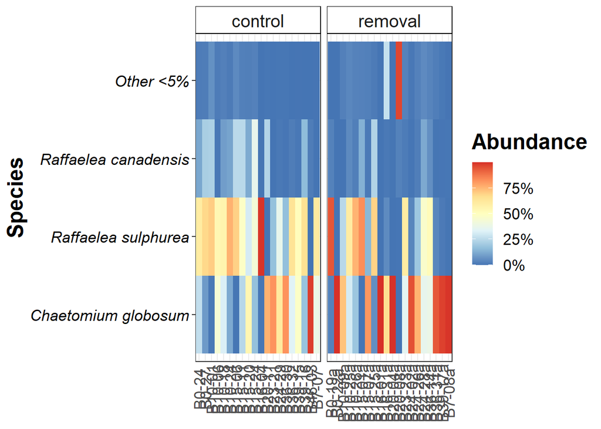

```r
pseq2 <- aggregate_rare(rel.R2nd, level = "Species", detection = 5/100, prevalence = 10/100)

pseqh2 <- pseq2 %>%
  psmelt()

pseqh2$Treatment<-factor(pseqh2$Treatment,levels=c("removal", "2nd-foundation"))
pseqh2$Species<-factor(pseqh2$Species,levels=c("Chaetomium_globosum", "Raffaelea_sulphurea", "Raffaelea_canadensis", "Other"), labels = c("Chaetomium globosum", "Raffaelea sulphurea", "Raffaelea canadensis", "Other <5%"))

p.heat <- ggplot(pseqh, aes(x = Sample, y = Species)) + geom_tile(aes(fill = Abundance))

# Change color
p.heat <- p.heat + scale_fill_distiller("Abundance", palette = "RdYlBu", labels = scales::percent) + theme_bw()

# Make bacterial names italics
p.heat <- p.heat + theme(axis.text.y = element_text(colour = 'black',
                                                    size = 10,
                                                    face = 'italic'))
# Make separate samples based on main variable
p.heat <- p.heat + facet_grid(~Treatment,
                              scales = "free") + rremove("x.text")

#Clean the x-axis
p.heat <- p.heat + theme(axis.title.x=element_blank(),
                     axis.text.x=element_blank(),
                     axis.ticks.x=element_blank())

# Clean the facet label box
p.heat <- p.heat + theme(legend.key = element_blank(),
                     strip.background = element_rect(colour="black", fill="white"))+
                      theme(strip.text = element_text(size = 15))

p.heat + theme(axis.text.x=element_text(angle = 90, size = 13))+
  theme(axis.title.y = element_text(size = 18, face = "bold"), axis.title.x = element_blank())+
  theme(axis.text.y = element_text(size = 13, face = "italic"))+
  theme(legend.text = element_text(size = 13))+
  theme(legend.title = element_text(size = 18, face = "bold"))
```

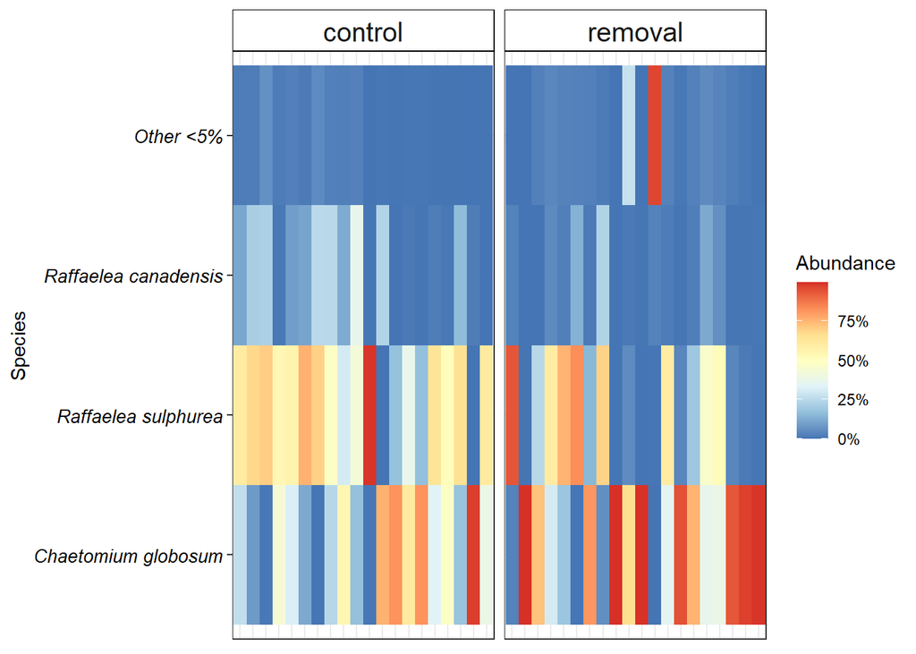

```r
p.heat
```

#### **Core taxa abundance plot**

define color bar

```r
colpal_fun <- c("lightskyblue", "gold", "goldenrod3", "forestgreen","peachpuff3", "darkolivegreen3")
```

**plot core taxa of control vs. removal with relative abundance**

relative Abundance

```r
ps4 <- prune_taxa(taxa_sums(rel.CR) > 0, rel.CR)
ps4 <- tax_glom(ps4, taxrank = 'Species')
psOrd4 = subset_taxa(ps4, Species =="Chaetomium_globosum" | Species == "Raffaelea_sulphurea" | Species == "Raffaelea_canadensis")
psctr = subset_samples(psOrd4, Treatment=="control")
#Melt and plot
melt3<-psmelt(psOrd4)
melt4<-psmelt(psctr)
melt3$Treament <- factor(melt3$Treatment, levels = c("control","removal"))
melt3$Species <- factor(melt3$Species, levels = c("Chaetomium_globosum", "Raffaelea_sulphurea", "Raffaelea_canadensis"), labels = c("Chaetomium globosum", "Raffaelea sulphurea", "Raffaelea canadensis"))
melt4$Treament <- factor(melt4$Treatment, levels = c("control","removal"))
melt4$Species <- factor(melt4$Species, levels = c("Chaetomium_globosum", "Raffaelea_sulphurea", "Raffaelea_canadensis"), labels = c("Chaetomium globosum", "Raffaelea sulphurea", "Raffaelea canadensis"))
a_mean <- melt4 %>%
  group_by(Species) %>%
  summarize(mean_val = mean(Abundance))
print(a_mean)
```

```
## # A tibble: 3 x 2
##   Species              mean_val
##   <fct>                   <dbl>
## 1 Chaetomium globosum     0.380
## 2 Raffaelea sulphurea     0.495
## 3 Raffaelea canadensis    0.110
```

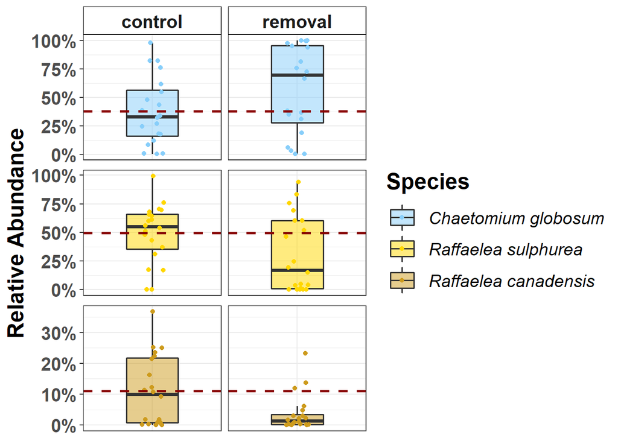

```r
p2<-ggplot(data = melt3, aes(x = Treatment, y = Abundance)) +
  geom_boxplot(aes(fill=Species),alpha=0.5,lwd=0.7, position = position_dodge(width = 0.3), width=0.45,outlier.shape = NA) + geom_jitter(aes(color = Species), height = 0, width = .1)+geom_hline(data= a_mean, aes(yintercept=mean_val), width=5,size=1,linetype="dashed", col = "darkred")+
  scale_fill_manual(values = colpal_fun, name = "Species")+
  scale_color_manual(values = colpal_fun, name = "Species")+
  labs(x = "", y = "Abundance\n")+
  facet_grid(Species~fct_relevel(Treatment, "control", "removal"), scales = "free")+theme_bw()
p2<-p2+ theme(legend.position="right")+ylab("Relative Abundance")
p2<-p2+ theme(legend.text=element_text(size=14, face = "italic"))+
  theme(legend.key = element_rect(color = NA, fill = NA),legend.key.size = unit(0.9, "cm"))+
  theme(legend.title = element_text(size = 18, face = "bold"))+
  scale_y_continuous(labels=percent_format())
abu2<-p2 + theme(strip.background =element_rect(fill="white", color="black"))+
  theme(strip.text.x = element_text(size = 15, face = "bold"))
Treatment2<-abu2+theme(axis.title.y = element_text(size=18, face="bold"))+theme(axis.text.y = element_text(size=15, face="bold")) +
  theme(axis.text.x = element_text(size=18, angle=90,face="bold"))+
  theme(axis.title.x = element_blank(), axis.text.x=element_blank(),
        axis.ticks.x=element_blank())+
  theme(strip.text.y = element_blank())
relAbcoreCR <- Treatment2 + theme(panel.spacing.y = unit(0.3, "cm"))

relAbcoreCR
```

**plot core taxa of removal vs. 2<sup>nd</sup> attempt with relative abundance**

```r
Treats <- c('removal' = "removal", '2nd-foundation' = "2nd-att.")
ps3 <- prune_taxa(taxa_sums(rel.R2nd) > 0, rel.R2nd)
ps3 <- tax_glom(ps3, taxrank = 'Species')
psOrd3 = subset_taxa(ps3, Species =="Chaetomium_globosum" | Species == "Raffaelea_sulphurea" | Species == "Raffaelea_canadensis")
psctr = subset_samples(psOrd3, Treatment=="removal")
#Melt and plot
melt<-psmelt(psOrd3)
melt2<-psmelt(psctr)
melt$Treament <- factor(melt$Treatment, levels = c("removal", "2nd-foundation"))
melt$Species <- factor(melt$Species, levels = c("Chaetomium_globosum", "Raffaelea_sulphurea", "Raffaelea_canadensis"), labels = c("Chaetomium globosum", "Raffaelea sulphurea", "Raffaelea canadensis"))
melt2$Treament <- factor(melt2$Treatment, levels = c("removal", "2nd-foundation"))
melt2$Species <- factor(melt2$Species, levels = c("Chaetomium_globosum", "Raffaelea_sulphurea", "Raffaelea_canadensis"), labels = c("Chaetomium globosum", "Raffaelea sulphurea", "Raffaelea canadensis"))
a_mean <- melt2 %>%
  group_by(Species) %>%
  summarize(mean_val = mean(Abundance))
print(a_mean)
```

```
## # A tibble: 3 x 2
##   Species              mean_val
##   <fct>                   <dbl>
## 1 Chaetomium globosum    0.575
## 2 Raffaelea sulphurea    0.308
## 3 Raffaelea canadensis   0.0376
```

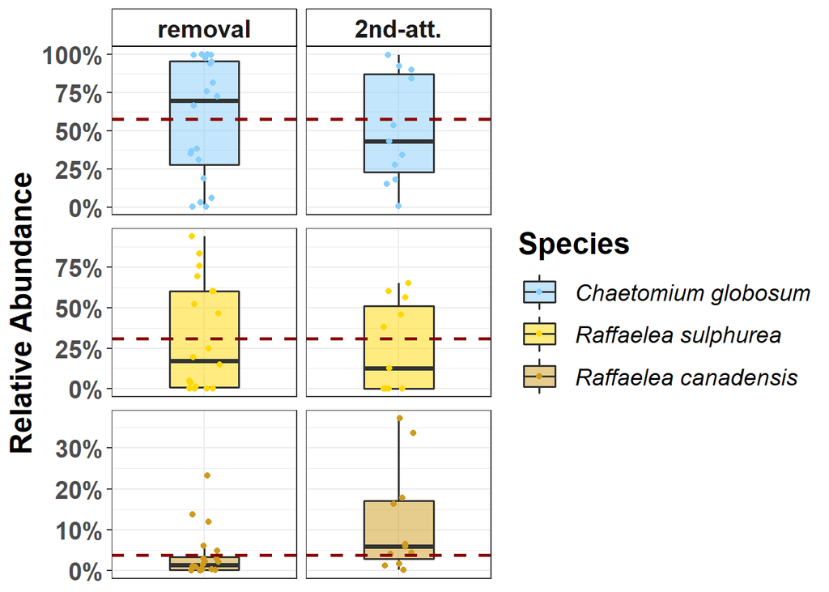

```r
p<-ggplot(data = melt, aes(x = Treatment, y = Abundance)) +
  geom_boxplot(aes(fill=Species),alpha=0.5,lwd=0.7, position = position_dodge(width = 0.3), width=0.45,outlier.shape = NA) + geom_jitter(aes(color = Species), height = 0, width = .1)+geom_hline(data= a_mean, aes(yintercept=mean_val), width=5,size=1,linetype="dashed", col = "darkred")+
  scale_fill_manual(values = colpal_fun, name = "Species")+
  scale_color_manual(values = colpal_fun, name = "Species")+
  labs(x = "", y = "Abundance\n")+
  facet_grid(Species~fct_relevel(Treatment, "removal", "2nd-foundation"), labeller = as_labeller(Treats), scales = "free")+
  theme_bw()
p<-p+ theme(legend.position="right")+
  ylab("Relative Abundance")
p<-p+ theme(legend.text=element_text(size=14, face = "italic"))+theme(legend.key = element_rect(color = NA, fill = NA),legend.key.size = unit(0.9, "cm"))+theme(legend.title = element_text(size = 18, face = "bold"))+
  scale_y_continuous(labels=percent_format())
abu<-p + theme(strip.background =element_rect(fill="white", color="black"))+
  theme(strip.text.x = element_text(size = 15, face = "bold"))
TreatmentCR<-abu+theme(axis.title.y = element_text(size=18, face="bold"))+
  theme(axis.text.y = element_text(size=15, face="bold")) +
  theme(axis.text.x = element_text(size=18, angle=90,face="bold"))+
  theme(axis.title.x = element_blank(), axis.text.x=element_blank(),
        axis.ticks.x=element_blank())+
  theme(strip.text.y = element_blank())
relAbcoreR2nd_fun <- TreatmentCR + theme(panel.spacing.y = unit(0.3, "cm"))

relAbcoreR2nd_fun
```

### **Ordination analysis**

#### Sample ordination

##### **NMDS**

```r
set.seed(1)
ordi.CR = ordinate(rel.CR, "NMDS", "bray", k=3, trymax=100)
```

```
## *** Solution reached
```

```r
ordi.CR$stress #0.03418721 --> good fit
```

```
## [1] 0.03418721
```

```r
set.seed(1)
ordi.R2nd = ordinate(rel.R2nd, "NMDS", "bray", k=3, trymax=100)
```

```
## *** Solution reached
```

```r
ordi.R2nd$stress #0.03165773
```

```
## [1] 0.03165773
```

plot NMDS

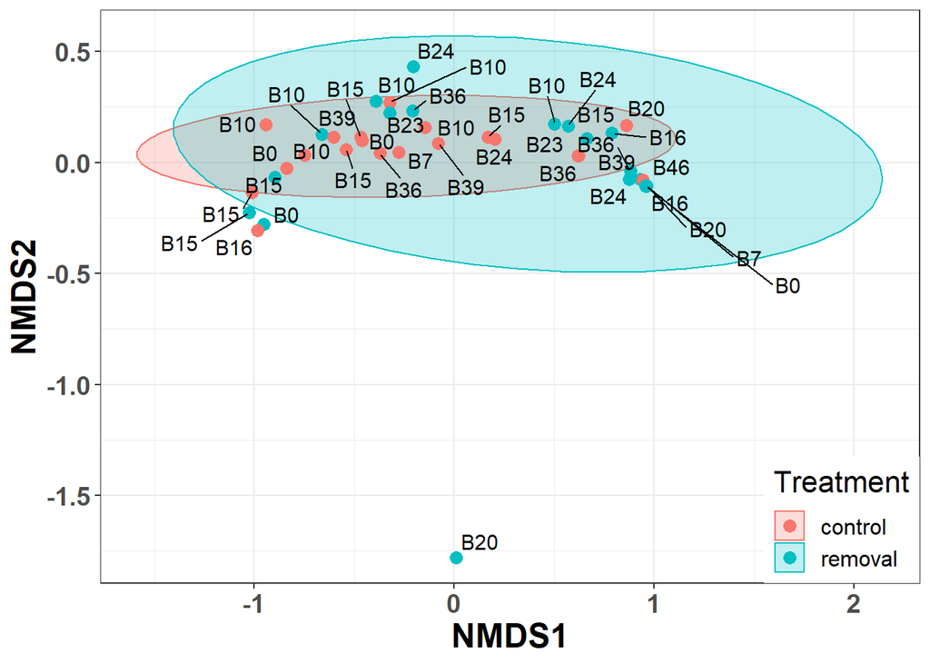

```r
NMDS_CR_fun <- plot_ordination(rel.CR, ordi.CR, color = "Treatment", axes=c(1,2))+
  stat_ellipse(level = 0.95, geom = "polygon", aes(fill = Treatment), alpha = 0.25)+
  geom_point(size=3, inherit.aes=T)+
  geom_text_repel(aes(label=Linage), color = "black", size = 4, max.overlaps = Inf)+
  theme_bw()+
  theme(legend.justification=c(1,0), legend.position=c(1,0))+
  theme(axis.text = element_text(size = 14, face = "bold"))+
  theme(axis.title = element_text(size = 18, face = "bold"))+
  theme(legend.text = element_text(size = 12))+
  theme(legend.title = element_text(size = 16))+
  theme(title = element_text(size = 18))

NMDS_CR_fun
```

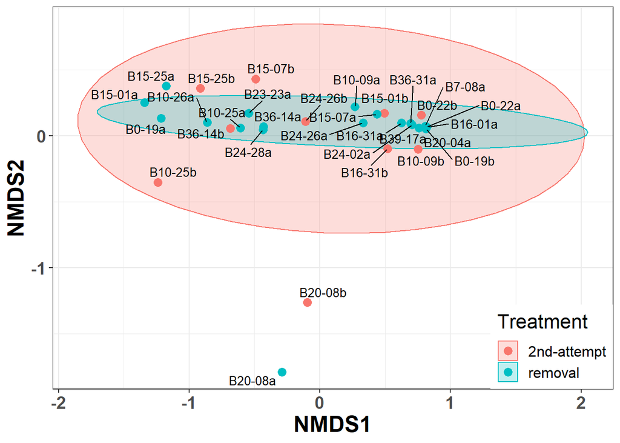

```r
sample_data(rel.R2nd)$Treatment <- as.factor(sample_data(rel.R2nd)$Treatment)
levels(sample_data(rel.R2nd)$Treatment) = c("2nd-attempt", "removal")

NMDS_R2nd_fun <- plot_ordination(rel.R2nd, ordi.R2nd, color = "Treatment", axes=c(1,2))+
  stat_ellipse(level = 0.95, geom = "polygon", aes(fill = Treatment), alpha = 0.25)+
  geom_point(size=3, inherit.aes=T)+
  geom_text_repel(aes(label=Sample), color = "black", size = 3.5, max.overlaps = Inf)+
  theme_bw()+
  theme(legend.justification=c(1,0), legend.position=c(1,0))+
  theme(axis.text = element_text(size = 14, face = "bold"))+
  theme(axis.title = element_text(size = 18, face = "bold"))+
  theme(legend.text = element_text(size = 12))+
  theme(legend.title = element_text(size = 16))+
  theme(title = element_text(size = 18))

NMDS_R2nd_fun
```

### **Permanova** for community-level multivariate comparisons

PERMANOVA quantifies multivariate community-level differences between groups.

```r
# Pick relative abundances (compositional) and sample metadata
otu.CR <- abundances(rel.CR)
meta.CR <- meta(rel.CR)

otu.R2nd <- abundances(rel.R2nd)
meta.R2nd <- meta(rel.R2nd)
```

#### PERMANOVA significance test for group-level differences

Now let us evaluate whether the Treatment has a significant effect on overall garden microbiota composition. Perform PERMANOVA:

```r
# control vs. removal
set.seed(1)
adonis2(distance(rel.CR, method = "bray") ~ Treatment + Linage, data = meta.CR)
```

```
## Permutation test for adonis under reduced model
## Terms added sequentially (first to last)
## Permutation: free
## Number of permutations: 999
##
## adonis2(formula = distance(rel.CR, method = "bray") ~ Treatment + Linage, data = meta.CR)
##           Df SumOfSqs      R2      F Pr(>F)
## Treatment  1   0.5422 0.08329 3.9420  0.032 *
## Linage    10   2.1167 0.32514 1.5389  0.107
## Residual  28   3.8513 0.59157
## Total     39   6.5102 1.00000
## ---
## Signif. codes:  0 '***' 0.001 '**' 0.01 '*' 0.05 '.' 0.1 ' ' 1
```

```r
#removal vs. 2^nd^ attempt
set.seed(1)
adonis2(distance(rel.R2nd, method = "bray") ~ Treatment + Linage, data = meta.R2nd)
```

```
## Permutation test for adonis under reduced model
## Terms added sequentially (first to last)
## Permutation: free
## Number of permutations: 999
##
## adonis2(formula = distance(rel.R2nd, method = "bray") ~ Treatment + Linage, data = meta.R2nd)
##           Df SumOfSqs      R2      F Pr(>F)
## Treatment  1   0.0951 0.01614 0.5438  0.641
## Linage     9   2.2989 0.39029 1.4612  0.132
## Residual  20   3.4962 0.59357
## Total     30   5.8902 1.00000
```

#### Checking the homogeneity condition

Check that variance homogeneity assumptions hold (to ensure the reliability of the results):

```r
# control vs. removal
dist <- vegdist(t(otu.CR))
dist.2 <- betadisper(dist, meta.CR$Treatment)
anova(dist.2)
```

```
## Analysis of Variance Table
##
## Response: Distances
##           Df  Sum Sq  Mean Sq F value Pr(>F)
## Groups     1 0.08264 0.082640  1.7441 0.1945
## Residuals 38 1.80055 0.047383
```

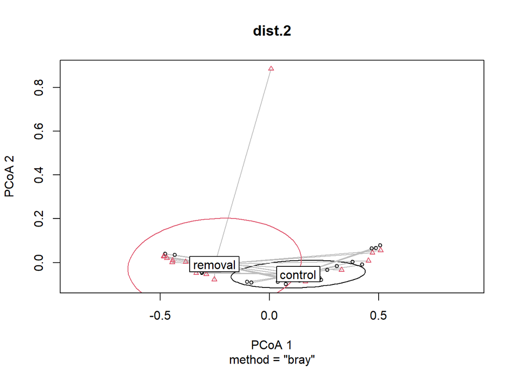

```r
plot(dist.2, hull = FALSE, ellipse = TRUE)
```

```r
# removal vs. 2^nd^ attempt
dist2 <- vegdist(t(otu.R2nd))
dist2.2 <- betadisper(dist2, meta.R2nd$Treatment)
anova(dist2.2)
```

```
## Analysis of Variance Table
##
## Response: Distances
##           Df  Sum Sq  Mean Sq F value Pr(>F)
## Groups     1 0.00751 0.007511  0.1497 0.7017
## Residuals 29 1.45538 0.050185
```

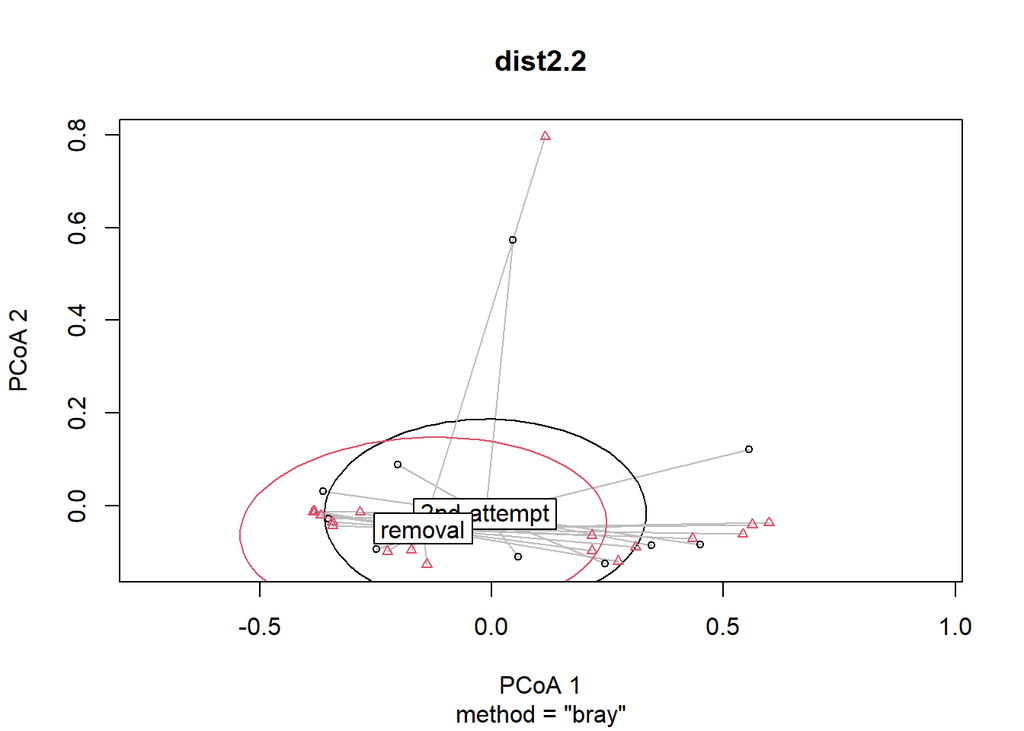

```r
plot(dist2.2, hull = FALSE, ellipse = TRUE)
```

## closer look at most abundant taxa

subset datasets of both combinations to most abundant Geni (each Chaetomiaceae or *Raffaelea*) (rel. abundances)

```r
CG_CR <- subset_taxa(rel.CR, Species == "Chaetomium_globosum")
CG_CR <- CG_CR %>%
  tax_glom(taxrank = "Species") %>%
  psmelt()

CG_R2nd <- subset_taxa(rel.R2nd, Species == "Chaetomium_globosum")
CG_R2nd <- CG_R2nd %>%
  tax_glom(taxrank = "Species") %>%
  psmelt()

RS_CR <- subset_taxa(rel.CR, Species == "Raffaelea_sulphurea")
RS_CR <- RS_CR %>%
  tax_glom(taxrank = "Species") %>%
  psmelt()

RS_R2nd <- subset_taxa(rel.R2nd, Species == "Raffaelea_sulphurea")
RS_R2nd <- RS_R2nd %>%
  tax_glom(taxrank = "Species") %>%
  psmelt()

RC_CR <- subset_taxa(rel.CR, Species == "Raffaelea_canadensis")
RC_CR <- RC_CR %>%
  tax_glom(taxrank = "Species") %>%
  psmelt()

RC_R2nd <- subset_taxa(rel.R2nd, Species == "Raffaelea_canadensis")
RC_R2nd <- RC_R2nd %>%
  tax_glom(taxrank = "Species") %>%
  psmelt()
```

### dataset *Raffaelea sulphurea*

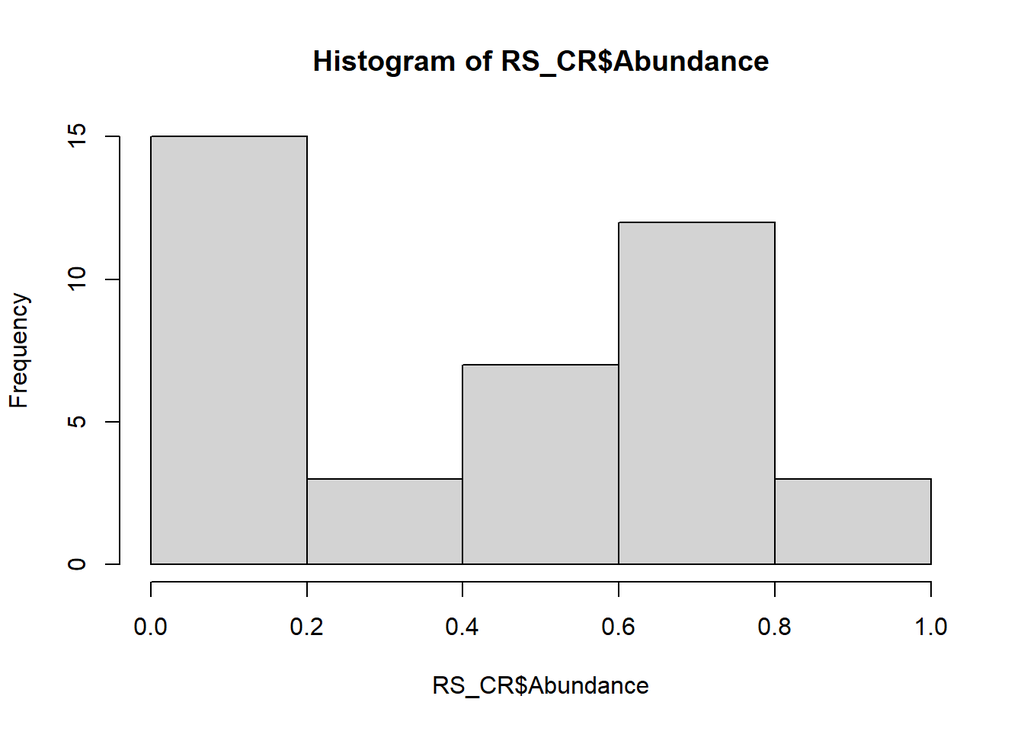

```r
RS_CR$Treatment <- as.factor(RS_CR$Treatment)
RS_CR <- within(RS_CR, Treatment <- relevel(Treatment, ref = "control"))

#control vs. removal
hist(RS_CR$Abundance)
```

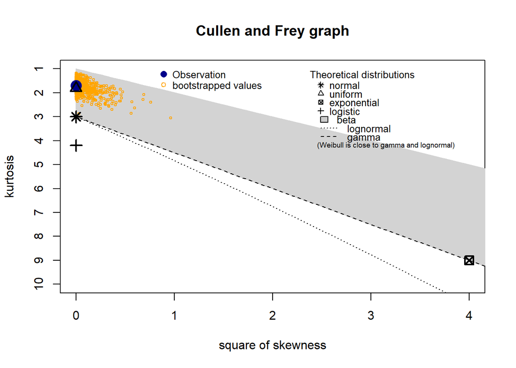

```
## summary statistics
## ------
## min:  0.0001473839   max:  0.9941497
## median:  0.4719555
## mean:  0.4012437
## estimated sd:  0.3078807
## estimated skewness:  0.01282538
## estimated kurtosis:  1.698684
```

```r
descdist(RS_CR$Abundance, boot = 1000)
```

```r
logistic <- function(p) log(p / (1-p) +0.01)

RS.mod <- lm(logistic(Abundance) ~ Treatment +  Linage, data = RS_CR)
summary(RS.mod)
```

```
##
## Call:
## lm(formula = logistic(Abundance) ~ Treatment + Linage, data = RS_CR)
##
## Residuals:
##     Min      1Q  Median      3Q     Max
## -3.6243 -1.1048 -0.0834  0.9287  4.8945
##
## Coefficients:
##                  Estimate Std. Error t value Pr(>|t|)
## (Intercept)        0.5922     1.0502   0.564   0.5773
## Treatmentremoval  -1.4670     0.6584  -2.228   0.0341 *
## LinageB10          0.4553     1.2510   0.364   0.7186
## LinageB15          0.1023     1.2510   0.082   0.9354
## LinageB16         -0.3513     1.5273  -0.230   0.8198
## LinageB20         -4.1102     1.5273  -2.691   0.0119 *
## LinageB23         -0.4007     1.7273  -0.232   0.8182
## LinageB24         -0.7373     1.4199  -0.519   0.6077
## LinageB36         -0.8169     1.4104  -0.579   0.5671
## LinageB39         -1.1260     1.5273  -0.737   0.4671
## LinageB46         -5.1286     2.2541  -2.275   0.0307 *
## LinageB7          -1.8596     1.7273  -1.077   0.2909
## ---
## Signif. codes:  0 '***' 0.001 '**' 0.01 '*' 0.05 '.' 0.1 ' ' 1
##
## Residual standard error: 1.995 on 28 degrees of freedom
## Multiple R-squared:  0.4629, Adjusted R-squared:  0.2519
## F-statistic: 2.194 on 11 and 28 DF,  p-value: 0.04585
```

```r
Anova(RS.mod, type = "II")
```

```
## Anova Table (Type II tests)
##
## Response: logistic(Abundance)
##            Sum Sq Df F value  Pr(>F)
## Treatment  19.752  1  4.9650 0.03407 *
## Linage     74.132 10  1.8634 0.09476 .
## Residuals 111.391 28
## ---
## Signif. codes:  0 '***' 0.001 '**' 0.01 '*' 0.05 '.' 0.1 ' ' 1
```

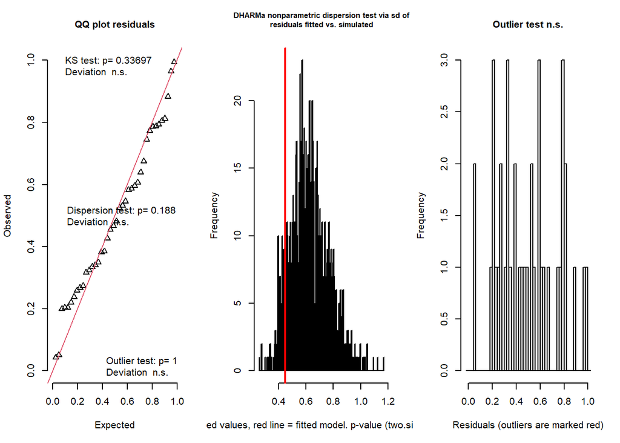

```
## $uniformity
##
##  One-sample Kolmogorov-Smirnov test
##
## data:  simulationOutput$scaledResiduals
## D = 0.149, p-value = 0.337
## alternative hypothesis: two-sided
##
##
## $dispersion
##
##  DHARMa nonparametric dispersion test via sd of residuals fitted vs.
##  simulated
##
## data:  simulationOutput
## dispersion = 0.71597, p-value = 0.188
## alternative hypothesis: two.sided
##
##
## $outliers
##
##  DHARMa outlier test based on exact binomial test with approximate
##  expectations
##
## data:  simulationOutput
## outliers at both margin(s) = 0, observations = 40, p-value = 1
## alternative hypothesis: true probability of success is not equal to 0.001998002
## 95 percent confidence interval:
##  0.0000000 0.0880973
## sample estimates:
## frequency of outliers (expected: 0.001998001998002 )
##                                                    0
```

```
## $uniformity
##
##  One-sample Kolmogorov-Smirnov test
##
## data:  simulationOutput$scaledResiduals
## D = 0.149, p-value = 0.337
## alternative hypothesis: two-sided
##
##
## $dispersion
##
##  DHARMa nonparametric dispersion test via sd of residuals fitted vs.
##  simulated
##
## data:  simulationOutput
## dispersion = 0.71597, p-value = 0.188
## alternative hypothesis: two.sided
##
##
## $outliers
##
##  DHARMa outlier test based on exact binomial test with approximate
##  expectations
##
## data:  simulationOutput
## outliers at both margin(s) = 0, observations = 40, p-value = 1
## alternative hypothesis: true probability of success is not equal to 0.001998002
## 95 percent confidence interval:
##  0.0000000 0.0880973
## sample estimates:
## frequency of outliers (expected: 0.001998001998002 )
##                                                    0
```

```r
res_RS <- simulateResiduals(fittedModel=RS.mod, n = 1000)
testResiduals(res_RS)
```

```
## Unable to calculate quantile regression for quantile 0.25. Possibly to few (unique) data points / predictions. Will be ommited in plots and significance calculations.
```

```
## Unable to calculate quantile regression for quantile 0.5. Possibly to few (unique) data points / predictions. Will be ommited in plots and significance calculations.
```

```
## Unable to calculate quantile regression for quantile 0.75. Possibly to few (unique) data points / predictions. Will be ommited in plots and significance calculations.
```

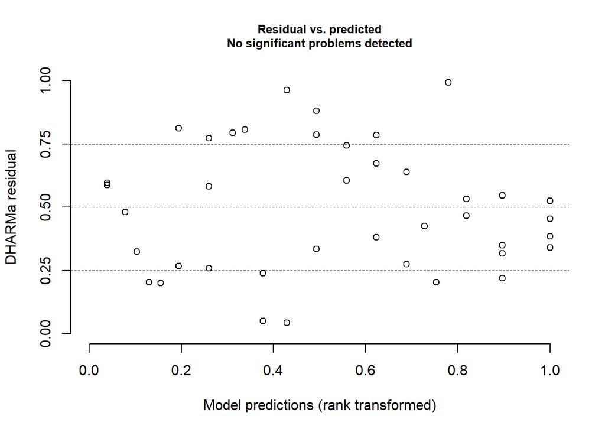

```r
plotResiduals(res_RS)
```

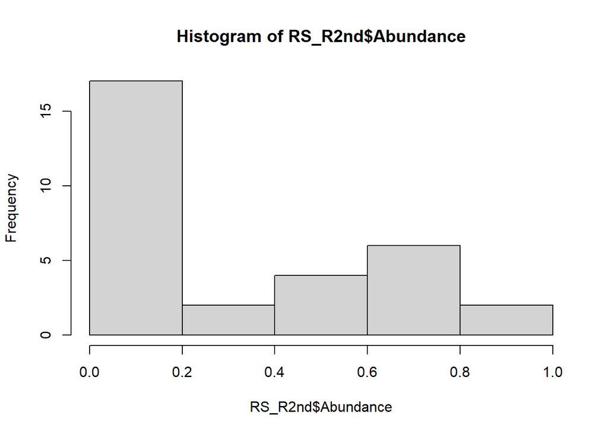

```r
#removal vs. 2^nd^ attempt
hist(RS_R2nd$Abundance)
```

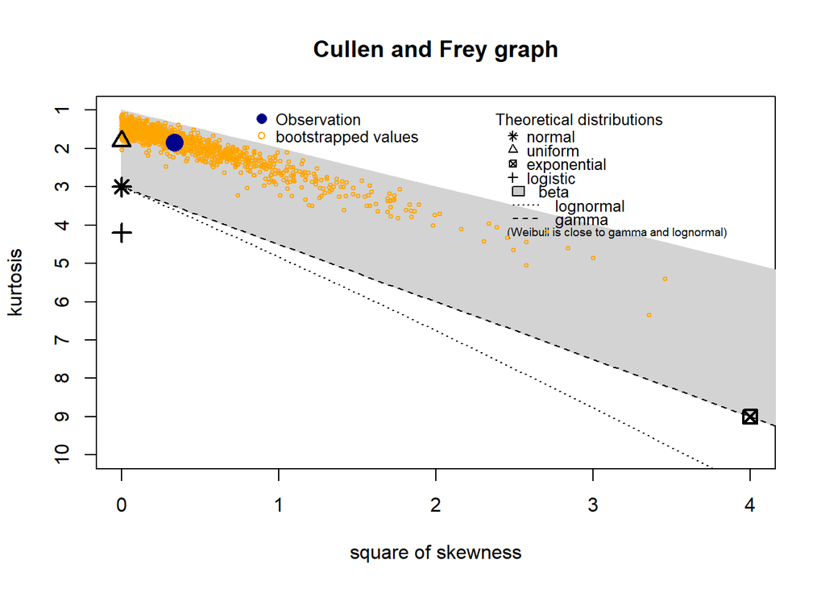

```
## summary statistics
## ------
## min:  0.0001473839   max:  0.9401502
## median:  0.1507833
## mean:  0.2882711
## estimated sd:  0.3090897
## estimated skewness:  0.5810069
## estimated kurtosis:  1.842227
```

```r
descdist(RS_R2nd$Abundance, boot = 1000)
```

```r
RS.mod2 <- lm(logistic(Abundance) ~ Treatment +  Linage, data = RS_R2nd)
summary(RS.mod2)
```

```
##
## Call:
## lm(formula = logistic(Abundance) ~ Treatment + Linage, data = RS_R2nd)
##
## Residuals:
##     Min      1Q  Median      3Q     Max
## -3.2509 -1.1071  0.0000  0.8656  5.0054
##
## Coefficients:
##                  Estimate Std. Error t value Pr(>|t|)
## (Intercept)       -3.1968     1.0690  -2.991  0.00723 **
## Treatmentremoval   0.9462     0.7833   1.208  0.24112
## LinageB10          1.8599     1.3367   1.391  0.17939
## LinageB15          2.5816     1.2841   2.011  0.05806 .
## LinageB16         -1.3710     1.5249  -0.899  0.37933
## LinageB20         -1.9304     1.5249  -1.266  0.22010
## LinageB23          2.6719     2.2583   1.183  0.25062
## LinageB24          1.2528     1.4202   0.882  0.38817
## LinageB36          1.8078     1.5249   1.185  0.24972
## LinageB39         -1.5180     2.2583  -0.672  0.50914
## LinageB7          -2.2154     2.2583  -0.981  0.33830
## ---
## Signif. codes:  0 '***' 0.001 '**' 0.01 '*' 0.05 '.' 0.1 ' ' 1
##
## Residual standard error: 1.989 on 20 degrees of freedom
## Multiple R-squared:  0.5235, Adjusted R-squared:  0.2853
## F-statistic: 2.197 on 10 and 20 DF,  p-value: 0.06429
```

```r
Anova(RS.mod2, type = "II")
```

```
## Anova Table (Type II tests)
##
## Response: logistic(Abundance)
##           Sum Sq Df F value  Pr(>F)
## Treatment  5.775  1  1.4594 0.24112
## Linage    84.589  9  2.3751 0.05143 .
## Residuals 79.142 20
## ---
## Signif. codes:  0 '***' 0.001 '**' 0.01 '*' 0.05 '.' 0.1 ' ' 1
```

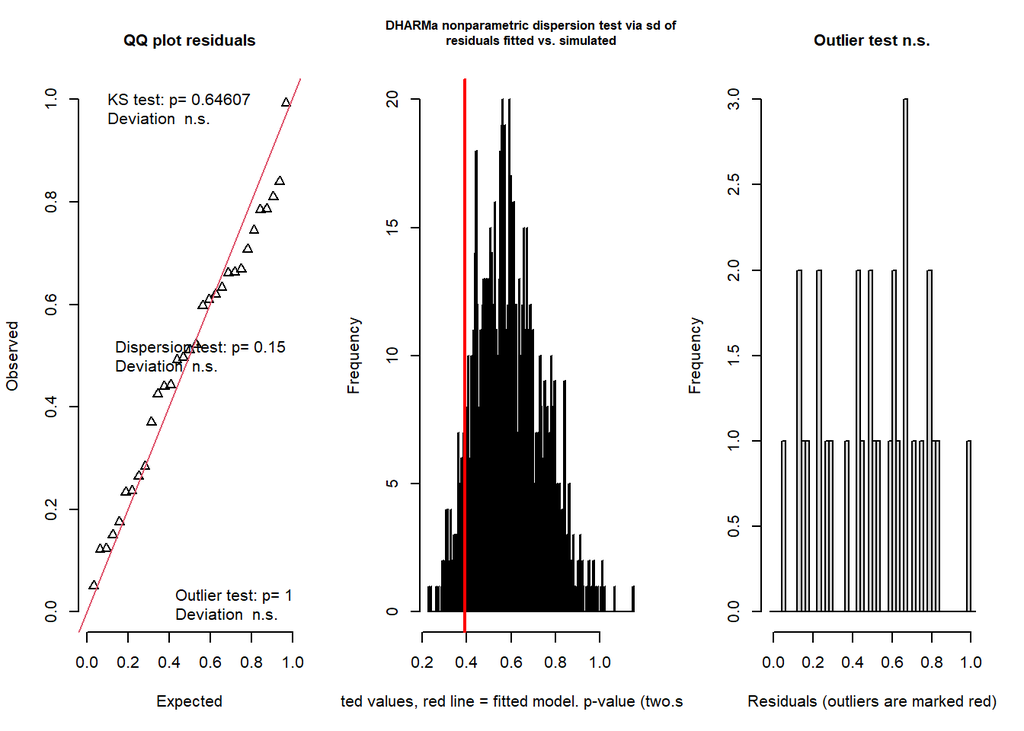

```
## $uniformity
##
##  One-sample Kolmogorov-Smirnov test
##
## data:  simulationOutput$scaledResiduals
## D = 0.12774, p-value = 0.6461
## alternative hypothesis: two-sided
##
##
## $dispersion
##
##  DHARMa nonparametric dispersion test via sd of residuals fitted vs.
##  simulated
##
## data:  simulationOutput
## dispersion = 0.66599, p-value = 0.15
## alternative hypothesis: two.sided
##
##
## $outliers
##
##  DHARMa outlier test based on exact binomial test with approximate
##  expectations
##
## data:  simulationOutput
## outliers at both margin(s) = 0, observations = 31, p-value = 1
## alternative hypothesis: true probability of success is not equal to 0.001998002
## 95 percent confidence interval:
##  0.0000000 0.1121887
## sample estimates:
## frequency of outliers (expected: 0.001998001998002 )
##                                                    0
```

```
## $uniformity
##
##  One-sample Kolmogorov-Smirnov test
##
## data:  simulationOutput$scaledResiduals
## D = 0.12774, p-value = 0.6461
## alternative hypothesis: two-sided
##
##
## $dispersion
##
##  DHARMa nonparametric dispersion test via sd of residuals fitted vs.
##  simulated
##
## data:  simulationOutput
## dispersion = 0.66599, p-value = 0.15
## alternative hypothesis: two.sided
##
##
## $outliers
##
##  DHARMa outlier test based on exact binomial test with approximate
##  expectations
##
## data:  simulationOutput
## outliers at both margin(s) = 0, observations = 31, p-value = 1
## alternative hypothesis: true probability of success is not equal to 0.001998002
## 95 percent confidence interval:
##  0.0000000 0.1121887
## sample estimates:
## frequency of outliers (expected: 0.001998001998002 )
##                                                    0
```

```r
res_RS2 <- simulateResiduals(fittedModel=RS.mod2, n = 1000)
testResiduals(res_RS2)
```

```
## Unable to calculate quantile regression for quantile 0.25. Possibly to few (unique) data points / predictions. Will be ommited in plots and significance calculations.
```

```
## Unable to calculate quantile regression for quantile 0.5. Possibly to few (unique) data points / predictions. Will be ommited in plots and significance calculations.
```

```
## Unable to calculate quantile regression for quantile 0.75. Possibly to few (unique) data points / predictions. Will be ommited in plots and significance calculations.
```

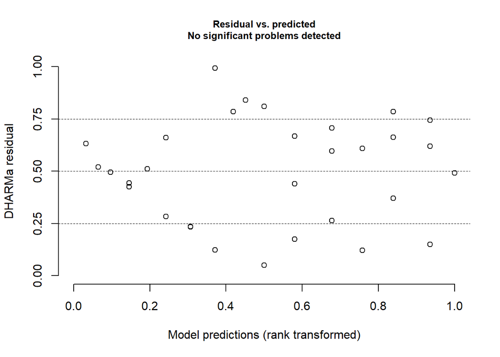

```r
plotResiduals(res_RS2)
```

### dataset *Raffaelea canadensis*

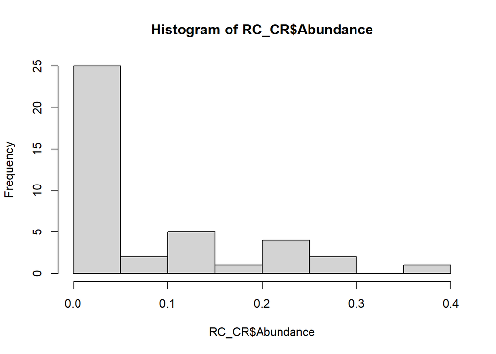

```r
RC_CR$Treatment <- as.factor(RC_CR$Treatment)
RC_CR <- within(RC_CR, Treatment <- relevel(Treatment, ref = "control"))

#control vs. removal
hist(RC_CR$Abundance)
```

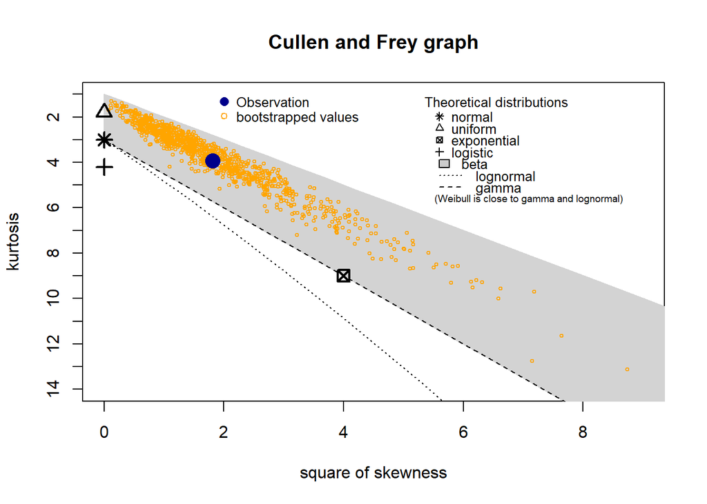

```
## summary statistics
## ------
## min:  0   max:  0.3683126
## median:  0.01966896
## mean:  0.0739891
## estimated sd:  0.09681155
## estimated skewness:  1.344583
## estimated kurtosis:  3.919206
```

```r
descdist(RC_CR$Abundance, boot = 1000)
```

```r
RC_CR.mod <- lm(logistic(Abundance) ~ Treatment +  Linage, data = RC_CR)
summary(RC_CR.mod)
```

```
##
## Call:
## lm(formula = logistic(Abundance) ~ Treatment + Linage, data = RC_CR)
##
## Residuals:
##      Min       1Q   Median       3Q      Max
## -1.78787 -0.68776  0.00395  0.58529  1.69934
##
## Coefficients:
##                  Estimate Std. Error t value Pr(>|t|)
## (Intercept)      -2.34061    0.56519  -4.141 0.000287 ***
## Treatmentremoval -0.80637    0.35431  -2.276 0.030700 *
## LinageB10        -0.21455    0.67328  -0.319 0.752341
## LinageB15         1.06255    0.67328   1.578 0.125759
## LinageB16        -1.45631    0.82196  -1.772 0.087320 .
## LinageB20        -0.05887    0.82196  -0.072 0.943417
## LinageB23        -1.34091    0.92961  -1.442 0.160269
## LinageB24        -0.47751    0.76417  -0.625 0.537111
## LinageB36        -0.98234    0.75902  -1.294 0.206162
## LinageB39        -0.69249    0.82196  -0.842 0.406652
## LinageB46        -1.20338    1.21312  -0.992 0.329710
## LinageB7         -1.70636    0.92961  -1.836 0.077064 .
## ---
## Signif. codes:  0 '***' 0.001 '**' 0.01 '*' 0.05 '.' 0.1 ' ' 1
##
## Residual standard error: 1.073 on 28 degrees of freedom
## Multiple R-squared:  0.5171, Adjusted R-squared:  0.3274
## F-statistic: 2.726 on 11 and 28 DF,  p-value: 0.01576
```

```r
Anova(RC_CR.mod, type = "II")
```

```
## Anova Table (Type II tests)
##
## Response: logistic(Abundance)
##           Sum Sq Df F value  Pr(>F)
## Treatment  5.968  1  5.1797 0.03070 *
## Linage    26.848 10  2.3301 0.03805 *
## Residuals 32.262 28
## ---
## Signif. codes:  0 '***' 0.001 '**' 0.01 '*' 0.05 '.' 0.1 ' ' 1
```

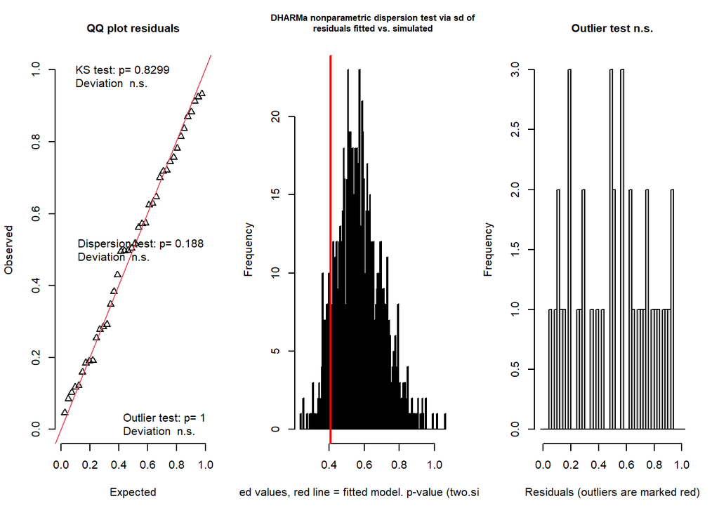

```
## $uniformity
##
##  One-sample Kolmogorov-Smirnov test
##
## data:  simulationOutput$scaledResiduals
## D = 0.095, p-value = 0.8299
## alternative hypothesis: two-sided
##
##
## $dispersion
##
##  DHARMa nonparametric dispersion test via sd of residuals fitted vs.
##  simulated
##
## data:  simulationOutput
## dispersion = 0.71597, p-value = 0.188
## alternative hypothesis: two.sided
##
##
## $outliers
##
##  DHARMa outlier test based on exact binomial test with approximate
##  expectations
##
## data:  simulationOutput
## outliers at both margin(s) = 0, observations = 40, p-value = 1
## alternative hypothesis: true probability of success is not equal to 0.001998002
## 95 percent confidence interval:
##  0.0000000 0.0880973
## sample estimates:
## frequency of outliers (expected: 0.001998001998002 )
##                                                    0
```

```
## $uniformity
##
##  One-sample Kolmogorov-Smirnov test
##
## data:  simulationOutput$scaledResiduals
## D = 0.095, p-value = 0.8299
## alternative hypothesis: two-sided
##
##
## $dispersion
##
##  DHARMa nonparametric dispersion test via sd of residuals fitted vs.
##  simulated
##
## data:  simulationOutput
## dispersion = 0.71597, p-value = 0.188
## alternative hypothesis: two.sided
##
##
## $outliers
##
##  DHARMa outlier test based on exact binomial test with approximate
##  expectations
##
## data:  simulationOutput
## outliers at both margin(s) = 0, observations = 40, p-value = 1
## alternative hypothesis: true probability of success is not equal to 0.001998002
## 95 percent confidence interval:
##  0.0000000 0.0880973
## sample estimates:
## frequency of outliers (expected: 0.001998001998002 )
##                                                    0
```

```r
res_RC_CR <- simulateResiduals(fittedModel=RC_CR.mod, n = 1000)
testResiduals(res_RC_CR)
```

```
## Unable to calculate quantile regression for quantile 0.25. Possibly to few (unique) data points / predictions. Will be ommited in plots and significance calculations.
```

```
## Unable to calculate quantile regression for quantile 0.5. Possibly to few (unique) data points / predictions. Will be ommited in plots and significance calculations.
```

```
## Unable to calculate quantile regression for quantile 0.75. Possibly to few (unique) data points / predictions. Will be ommited in plots and significance calculations.
```

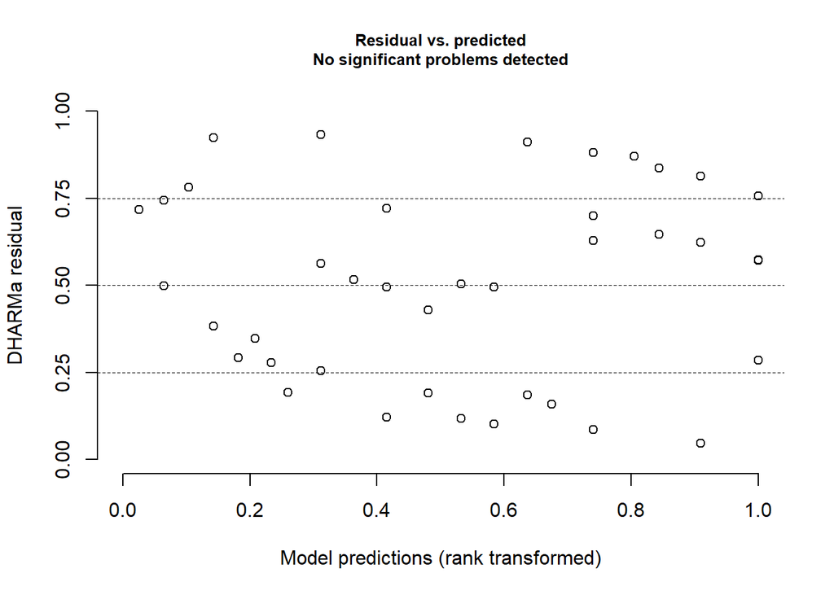

```r
plotResiduals(res_RC_CR)
```

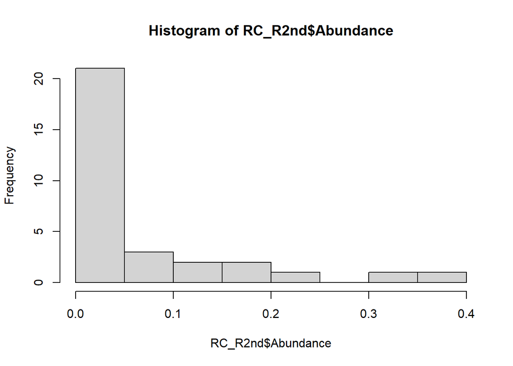

```r
#removal vs. 2^nd^ attempt
hist(RC_R2nd$Abundance)
```

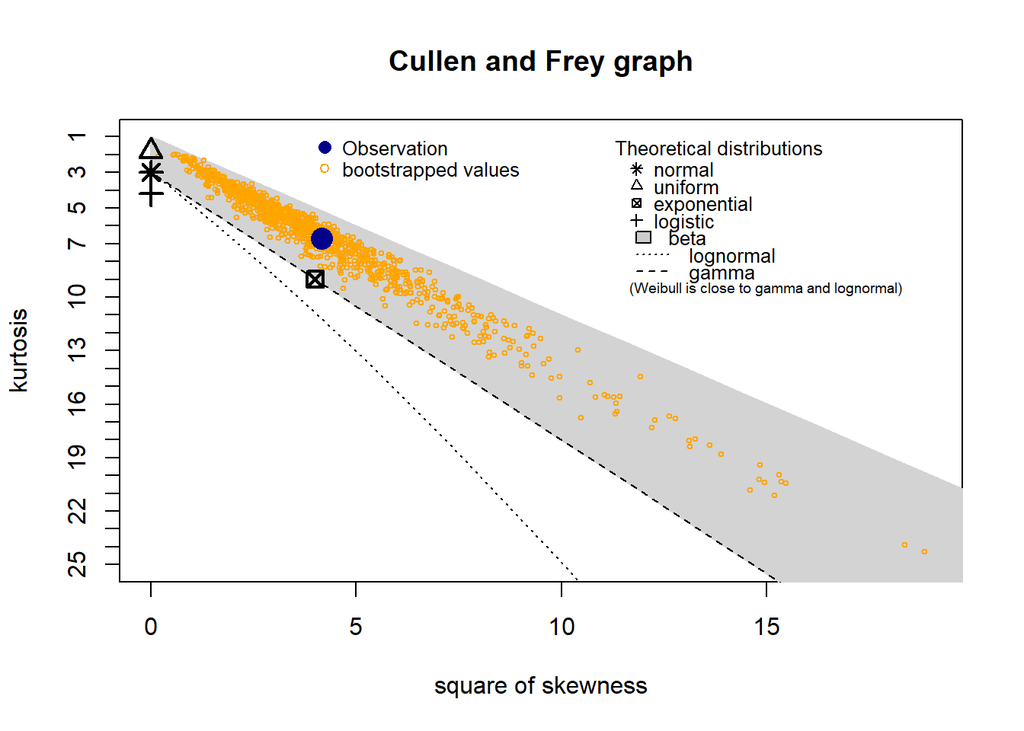

```
## summary statistics
## ------
## min:  9.825596e-05   max:  0.3730086
## median:  0.02241167
## mean:  0.06594247
## estimated sd:  0.09730933
## estimated skewness:  2.038278
## estimated kurtosis:  6.698162
```

```r
descdist(RC_R2nd$Abundance, boot = 1000)
```

```r
RC_R2nd.mod <- lm(logistic(Abundance) ~ Treatment + Linage, data = RC_R2nd)
summary(RC_R2nd.mod)
```

```
##
## Call:
## lm(formula = logistic(Abundance) ~ Treatment + Linage, data = RC_R2nd)
##
## Residuals:
##      Min       1Q   Median       3Q      Max
## -1.99379 -0.41802 -0.06997  0.54212  1.71614
##
## Coefficients:
##                  Estimate Std. Error t value Pr(>|t|)
## (Intercept)       -3.1885     0.6183  -5.157 4.79e-05 ***
## Treatmentremoval  -0.9391     0.4530  -2.073   0.0513 .
## LinageB10          0.9697     0.7731   1.254   0.2242
## LinageB15          1.3776     0.7427   1.855   0.0784 .
## LinageB16         -0.2286     0.8820  -0.259   0.7981
## LinageB20          1.0399     0.8820   1.179   0.2522
## LinageB23          0.4908     1.3061   0.376   0.7110
## LinageB24          0.7313     0.8214   0.890   0.3839
## LinageB36          0.4945     0.8820   0.561   0.5812
## LinageB39         -0.1815     1.3061  -0.139   0.8909
## LinageB7          -0.1675     1.3061  -0.128   0.8992
## ---
## Signif. codes:  0 '***' 0.001 '**' 0.01 '*' 0.05 '.' 0.1 ' ' 1
##
## Residual standard error: 1.151 on 20 degrees of freedom
## Multiple R-squared:  0.4011, Adjusted R-squared:  0.1016
## F-statistic: 1.339 on 10 and 20 DF,  p-value: 0.2765
```

```r
Anova(RC_R2nd.mod, type = "II")
```

```
## Anova Table (Type II tests)
##
## Response: logistic(Abundance)
##            Sum Sq Df F value  Pr(>F)
## Treatment  5.6882  1  4.2971 0.05131 .
## Linage     9.4990  9  0.7973 0.62301
## Residuals 26.4747 20
## ---
## Signif. codes:  0 '***' 0.001 '**' 0.01 '*' 0.05 '.' 0.1 ' ' 1
```

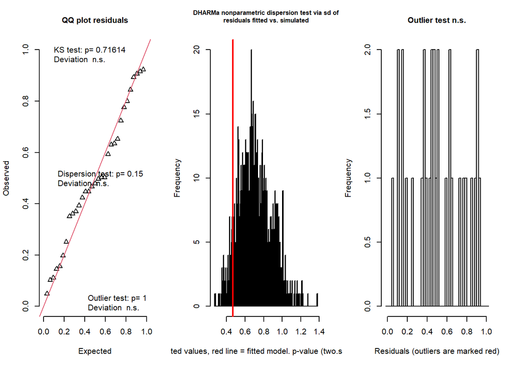

```
## $uniformity
##
##  One-sample Kolmogorov-Smirnov test
##
## data:  simulationOutput$scaledResiduals
## D = 0.12519, p-value = 0.7161
## alternative hypothesis: two-sided
##
##
## $dispersion
##
##  DHARMa nonparametric dispersion test via sd of residuals fitted vs.
##  simulated
##
## data:  simulationOutput
## dispersion = 0.66599, p-value = 0.15
## alternative hypothesis: two.sided
##
##
## $outliers
##
##  DHARMa outlier test based on exact binomial test with approximate
##  expectations
##
## data:  simulationOutput
## outliers at both margin(s) = 0, observations = 31, p-value = 1
## alternative hypothesis: true probability of success is not equal to 0.001998002
## 95 percent confidence interval:
##  0.0000000 0.1121887
## sample estimates:
## frequency of outliers (expected: 0.001998001998002 )
##                                                    0
```

```
## $uniformity
##
##  One-sample Kolmogorov-Smirnov test
##
## data:  simulationOutput$scaledResiduals
## D = 0.12519, p-value = 0.7161
## alternative hypothesis: two-sided
##
##
## $dispersion
##
##  DHARMa nonparametric dispersion test via sd of residuals fitted vs.
##  simulated
##
## data:  simulationOutput
## dispersion = 0.66599, p-value = 0.15
## alternative hypothesis: two.sided
##
##
## $outliers
##
##  DHARMa outlier test based on exact binomial test with approximate
##  expectations
##
## data:  simulationOutput
## outliers at both margin(s) = 0, observations = 31, p-value = 1
## alternative hypothesis: true probability of success is not equal to 0.001998002
## 95 percent confidence interval:
##  0.0000000 0.1121887
## sample estimates:
## frequency of outliers (expected: 0.001998001998002 )
##                                                    0
```

```r
res_RC_R2nd <- simulateResiduals(fittedModel=RC_R2nd.mod, n = 1000)
testResiduals(res_RC_R2nd)
```

```
## Unable to calculate quantile regression for quantile 0.25. Possibly to few (unique) data points / predictions. Will be ommited in plots and significance calculations.
```

```
## Unable to calculate quantile regression for quantile 0.5. Possibly to few (unique) data points / predictions. Will be ommited in plots and significance calculations.
```

```
## Unable to calculate quantile regression for quantile 0.75. Possibly to few (unique) data points / predictions. Will be ommited in plots and significance calculations.
```

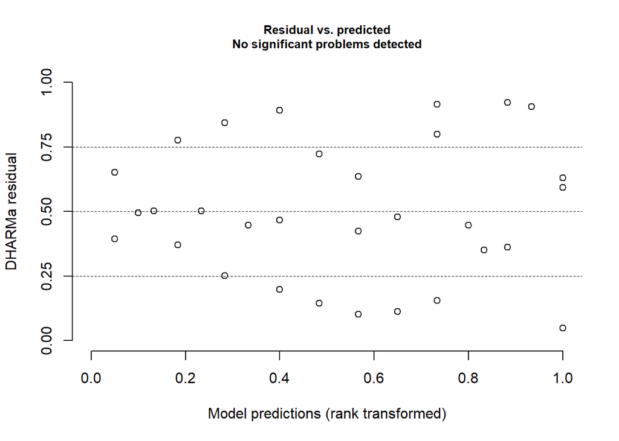

```r
plotResiduals(res_RC_R2nd)
```

### dataset *Chaetomium globosum*

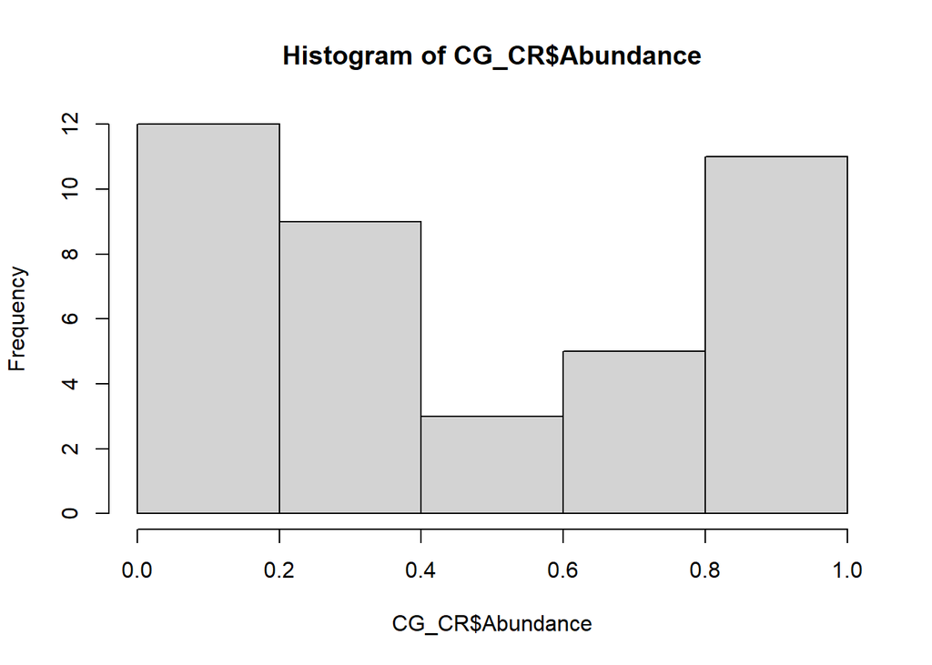

```r
CG_CR$Treatment <- as.factor(CG_CR$Treatment)
CG_CR <- within(CG_CR, Treatment <- relevel(Treatment, ref = "control"))

#control vs. removal
hist(CG_CR$Abundance)
```

```r
CG_CR.mod <- lm(logistic(Abundance) ~ Treatment + Linage, data = CG_CR)
summary(CG_CR.mod)
```

```
##
## Call:
## lm(formula = logistic(Abundance) ~ Treatment + Linage, data = CG_CR)
##
## Residuals:
##     Min      1Q  Median      3Q     Max
## -5.9174 -1.8652 -0.0126  1.5953  6.1238
##
## Coefficients:
##                  Estimate Std. Error t value Pr(>|t|)
## (Intercept)       -0.9525     1.5687  -0.607   0.5486
## Treatmentremoval   1.8051     0.9834   1.836   0.0771 .
## LinageB10         -0.9916     1.8687  -0.531   0.5999
## LinageB15         -1.5876     1.8687  -0.850   0.4027
## LinageB16          1.3350     2.2814   0.585   0.5631
## LinageB20          0.5364     2.2814   0.235   0.8158
## LinageB23          0.5182     2.5801   0.201   0.8423
## LinageB24          0.6024     2.1210   0.284   0.7785
## LinageB36          0.8342     2.1067   0.396   0.6951
## LinageB39          1.0642     2.2814   0.466   0.6445
## LinageB46          4.8388     3.3670   1.437   0.1618
## LinageB7           2.3669     2.5801   0.917   0.3668
## ---
## Signif. codes:  0 '***' 0.001 '**' 0.01 '*' 0.05 '.' 0.1 ' ' 1
##
## Residual standard error: 2.979 on 28 degrees of freedom
## Multiple R-squared:  0.2958, Adjusted R-squared:  0.01916
## F-statistic: 1.069 on 11 and 28 DF,  p-value: 0.4186
```

```r
Anova(CG_CR.mod, type = "II")
```

```
## Anova Table (Type II tests)
##
## Response: logistic(Abundance)
##            Sum Sq Df F value  Pr(>F)
## Treatment  29.908  1  3.3695 0.07706 .
## Linage     72.260 10  0.8141 0.61777
## Residuals 248.530 28
## ---
## Signif. codes:  0 '***' 0.001 '**' 0.01 '*' 0.05 '.' 0.1 ' ' 1
```

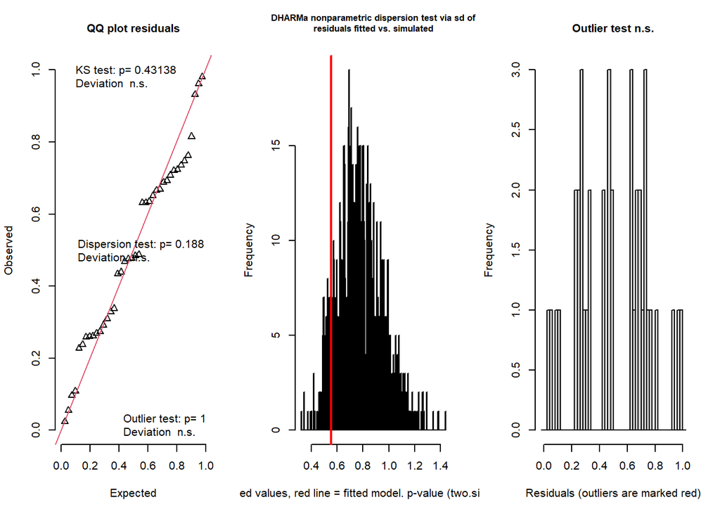

```
## $uniformity
##
##  One-sample Kolmogorov-Smirnov test
##
## data:  simulationOutput$scaledResiduals
## D = 0.138, p-value = 0.4314
## alternative hypothesis: two-sided
##
##
## $dispersion
##
##  DHARMa nonparametric dispersion test via sd of residuals fitted vs.
##  simulated
##
## data:  simulationOutput
## dispersion = 0.71597, p-value = 0.188
## alternative hypothesis: two.sided
##
##
## $outliers
##
##  DHARMa outlier test based on exact binomial test with approximate
##  expectations
##
## data:  simulationOutput
## outliers at both margin(s) = 0, observations = 40, p-value = 1
## alternative hypothesis: true probability of success is not equal to 0.001998002
## 95 percent confidence interval:
##  0.0000000 0.0880973
## sample estimates:
## frequency of outliers (expected: 0.001998001998002 )
##                                                    0
```

```
## $uniformity
##
##  One-sample Kolmogorov-Smirnov test
##
## data:  simulationOutput$scaledResiduals
## D = 0.138, p-value = 0.4314
## alternative hypothesis: two-sided
##
##
## $dispersion
##
##  DHARMa nonparametric dispersion test via sd of residuals fitted vs.
##  simulated
##
## data:  simulationOutput
## dispersion = 0.71597, p-value = 0.188
## alternative hypothesis: two.sided
##
##
## $outliers
##
##  DHARMa outlier test based on exact binomial test with approximate
##  expectations
##
## data:  simulationOutput
## outliers at both margin(s) = 0, observations = 40, p-value = 1
## alternative hypothesis: true probability of success is not equal to 0.001998002
## 95 percent confidence interval:
##  0.0000000 0.0880973
## sample estimates:
## frequency of outliers (expected: 0.001998001998002 )
##                                                    0
```

```r
res_CG_CR.mod <- simulateResiduals(CG_CR.mod, n = 1000)
testResiduals(res_CG_CR.mod)
```

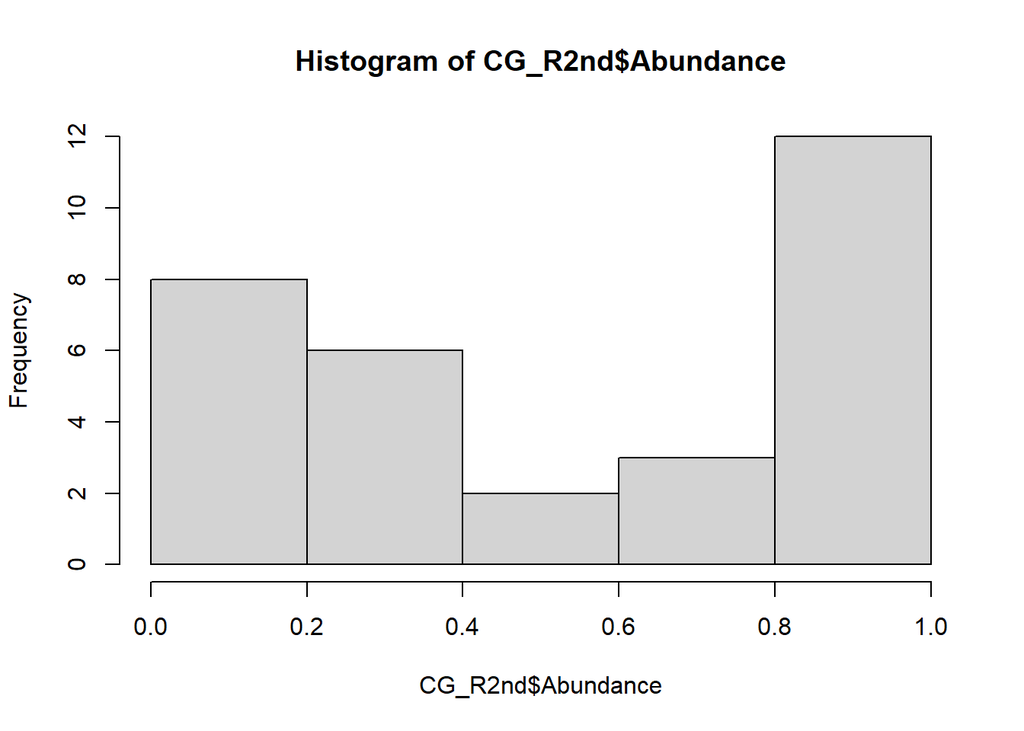

```r
#removal vs. 2^nd^ attempt
hist(CG_R2nd$Abundance)
```

```r
CG_R2nd.mod <- lm(logistic(Abundance) ~ Treatment + Linage, data = CG_R2nd)
summary(CG_R2nd.mod)
```

```
##
## Call:
## lm(formula = logistic(Abundance) ~ Treatment + Linage, data = CG_R2nd)
##
## Residuals:
##     Min      1Q  Median      3Q     Max
## -6.1054 -1.3363 -0.0285  2.0304  5.6895
##
## Coefficients:
##                  Estimate Std. Error t value Pr(>|t|)
## (Intercept)        2.5165     1.7758   1.417   0.1719
## Treatmentremoval   0.3940     1.3012   0.303   0.7652
## LinageB10         -3.3741     2.2207  -1.519   0.1443
## LinageB15         -3.7326     2.1332  -1.750   0.0955 .
## LinageB16          0.1315     2.5333   0.052   0.9591
## LinageB20         -2.8706     2.5333  -1.133   0.2706
## LinageB23         -3.5060     3.7516  -0.935   0.3612
## LinageB24         -1.8909     2.3593  -0.801   0.4323
## LinageB36         -2.3398     2.5333  -0.924   0.3667
## LinageB39          0.7595     3.7516   0.202   0.8416
## LinageB7           2.1701     3.7516   0.578   0.5694
## ---
## Signif. codes:  0 '***' 0.001 '**' 0.01 '*' 0.05 '.' 0.1 ' ' 1
##
## Residual standard error: 3.305 on 20 degrees of freedom
## Multiple R-squared:  0.2923, Adjusted R-squared:  -0.06151
## F-statistic: 0.8262 on 10 and 20 DF,  p-value: 0.6092
```

```r
Anova(CG_R2nd.mod, type = "II")
```

```
## Anova Table (Type II tests)
##
## Response: logistic(Abundance)
##            Sum Sq Df F value Pr(>F)
## Treatment   1.001  1  0.0917 0.7652
## Linage     85.990  9  0.8748 0.5623
## Residuals 218.424 20
```

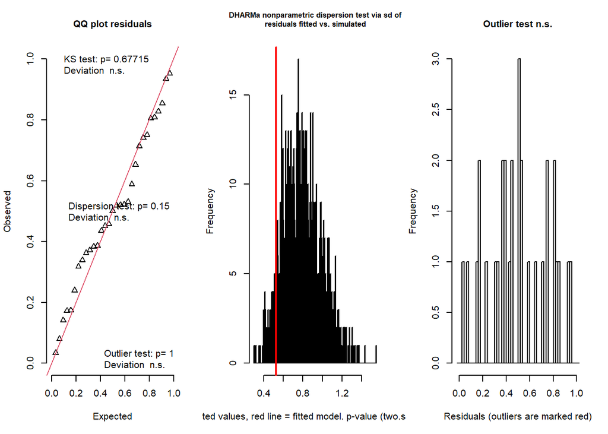

```
## $uniformity
##
##  One-sample Kolmogorov-Smirnov test
##
## data:  simulationOutput$scaledResiduals
## D = 0.12445, p-value = 0.6771
## alternative hypothesis: two-sided
##
##
## $dispersion
##
##  DHARMa nonparametric dispersion test via sd of residuals fitted vs.
##  simulated
##
## data:  simulationOutput
## dispersion = 0.66599, p-value = 0.15
## alternative hypothesis: two.sided
##
##
## $outliers
##
##  DHARMa outlier test based on exact binomial test with approximate
##  expectations
##
## data:  simulationOutput
## outliers at both margin(s) = 0, observations = 31, p-value = 1
## alternative hypothesis: true probability of success is not equal to 0.001998002
## 95 percent confidence interval:
##  0.0000000 0.1121887
## sample estimates:
## frequency of outliers (expected: 0.001998001998002 )
##                                                    0
```

```
## $uniformity
##
##  One-sample Kolmogorov-Smirnov test
##
## data:  simulationOutput$scaledResiduals
## D = 0.12445, p-value = 0.6771
## alternative hypothesis: two-sided
##
##
## $dispersion
##
##  DHARMa nonparametric dispersion test via sd of residuals fitted vs.
##  simulated
##
## data:  simulationOutput
## dispersion = 0.66599, p-value = 0.15
## alternative hypothesis: two.sided
##
##
## $outliers
##
##  DHARMa outlier test based on exact binomial test with approximate
##  expectations
##
## data:  simulationOutput
## outliers at both margin(s) = 0, observations = 31, p-value = 1
## alternative hypothesis: true probability of success is not equal to 0.001998002
## 95 percent confidence interval:
##  0.0000000 0.1121887
## sample estimates:
## frequency of outliers (expected: 0.001998001998002 )
##                                                    0
```

```r
res_CG_R2nd.mod <- simulateResiduals(CG_R2nd.mod, n = 1000)
testResiduals(res_CG_R2nd.mod)
```

## testing difference of ‘successfull’ vs. ‘failed’ nests

create subset of samples from ‘removal’ group

```r
REM <- subset_samples(rel.R2nd, Treatment == "removal")
REM <- prune_taxa(taxa_sums(REM) > 0, REM)

sample_data(REM)
```

```
##          Sample   Nest Linage Treatment age_sampling_d. Group ColSums
## B0-19a   B0-19a  B0-19     B0   removal              31 Fungi    8655
## B0-22a   B0-22a  B0-22     B0   removal              31 Fungi   19669
## B10-09a B10-09a B10-09    B10   removal              30 Fungi   26662
## B10-25a B10-25a B10-25    B10   removal              30 Fungi   24345
## B10-26a B10-26a B10-26    B10   removal              30 Fungi   26861
## B15-01a B15-01a B15-01    B15   removal              33 Fungi   12127
## B15-07a B15-07a B15-07    B15   removal              29 Fungi   19916
## B15-25a B15-25a B15-25    B15   removal              28 Fungi    8107
## B16-01a B16-01a B16-01    B16   removal              32 Fungi   20355
## B16-31a B16-31a B16-31    B16   removal              30 Fungi   15800
## B20-04a B20-04a B20-04    B20   removal              35 Fungi   34274
## B20-08a B20-08a B20-08    B20   removal              31 Fungi   27572
## B23-23a B23-23a B23-23    B23   removal              32 Fungi   26875
## B24-02a B24-02a B24-02    B24   removal              32 Fungi    1087
## B24-26a B24-26a B24-26    B24   removal              32 Fungi   16017
## B24-28a B24-28a B24-28    B24   removal              32 Fungi   19882
## B36-14a B36-14a B36-14    B36   removal              19 Fungi    8615
## B36-31a B36-31a B36-31    B36   removal              32 Fungi   17279
## B39-17a B39-17a B39-17    B39   removal              31 Fungi   12233
## B7-08a   B7-08a  B7-08     B7   removal              33 Fungi    4694
```

```r
suc = c("successfull", "successfull", "successfull", "successfull", "failed", "successfull", "successfull", "successfull", "failed", "successfull", "failed", "successfull", "failed", "failed", "successfull", "failed", "successfull", "failed", "failed", "failed")
sample_data(REM)$success <- suc

dfREM <- REM %>%
  tax_glom(taxrank = "Species") %>%
  psmelt()
```

#### Permanova on data REM

```r
otu.REM <- abundances(REM)
meta.REM <- meta(REM)

set.seed(1)
adonis2(distance(REM, method = "bray") ~ success, data = meta.REM)
```

```
## Permutation test for adonis under reduced model
## Terms added sequentially (first to last)
## Permutation: free
## Number of permutations: 999
##
## adonis2(formula = distance(REM, method = "bray") ~ success, data = meta.REM)
##          Df SumOfSqs      R2      F Pr(>F)
## success   1   0.3363 0.09082 1.7981  0.164
## Residual 18   3.3662 0.90918
## Total    19   3.7024 1.00000
```

```r
dist <- vegdist(t(otu.REM))
dist.2 <- betadisper(dist, meta.REM$success)
anova(dist.2)
```

```
## Analysis of Variance Table
##
## Response: Distances
##           Df  Sum Sq  Mean Sq F value Pr(>F)
## Groups     1 0.15332 0.153318   2.109 0.1636
## Residuals 18 1.30858 0.072699
```

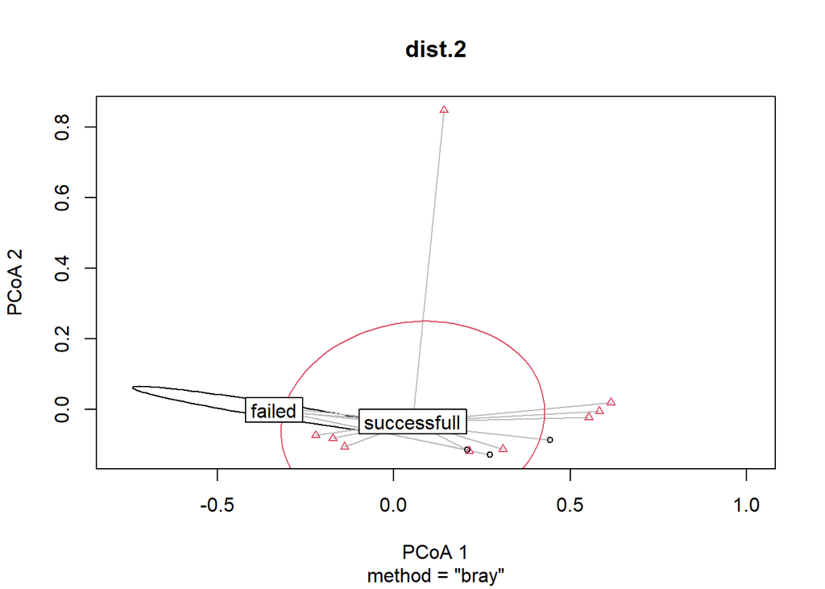

```r
plot(dist.2, hull = FALSE, ellipse = TRUE)
```

prepare data and plot

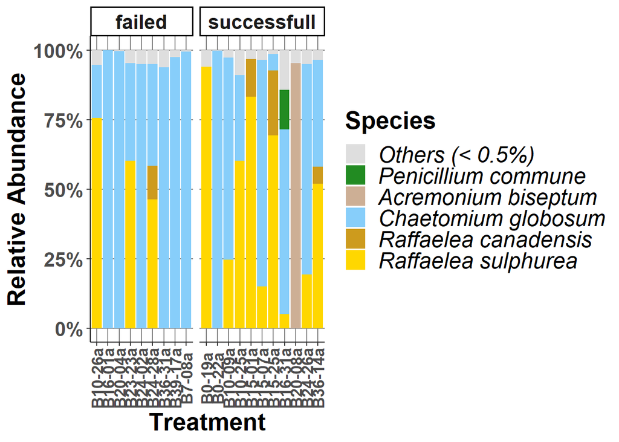

```r
dfREM.plot <-dfREM
dfREM.plot$Species<-as.character(dfREM.plot$Species)
dfREM.plot$Species[dfREM.plot$Abundance<0.05]<-"Others"
dfREM.plot$Species<-factor(dfREM.plot$Species, levels = c("Others", "Penicillium_commune", "Acremonium_biseptum", "Chaetomium_globosum","Raffaelea_canadensis", "Raffaelea_sulphurea"), labels = c("Others (< 0.5%)", "Penicillium commune", "Acremonium biseptum", "Chaetomium globosum", "Raffaelea canadensis", "Raffaelea sulphurea"))


Fungi_Success_plot <-ggplot(dfREM.plot, aes(x = Sample, y = Abundance, fill = Species)) +
  geom_bar(stat = "identity", color = NA,  position="fill") +
  scale_fill_manual(values = Plot_colors_s, name = "Species") +
  facet_grid(~success, scales = "free_x", space = "free_x")

FS<-Fungi_Success_plot +
  theme(plot.title = element_text(size = 20, face = "bold")) +
  theme_classic()+           #gets rid of background
  theme(panel.grid.major = element_line(colour = "grey50"))+
  labs(x="Treatment", y="Relative Abundance")+
  scale_y_continuous(labels=percent_format())+
  theme(axis.text.x=element_text(size = 13, angle = 90, vjust = 0.5))+
  theme(text = element_text(size=20, face = "bold"))+
  theme(legend.title = element_text(size = 20), legend.text = element_text(size = 18))+
  theme(legend.text = element_text(face = "italic"))

FS
```

#### plot core taxa of successfull vs. failed nests with relative abundance

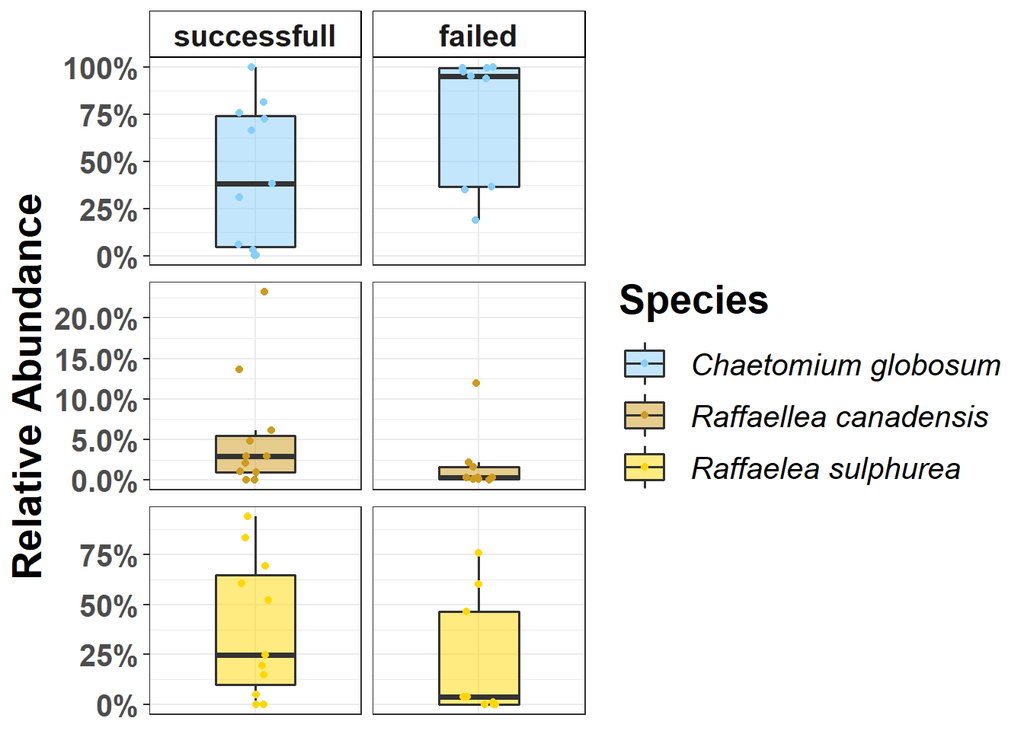

```r
dfREM.sub <- subset(dfREM, Species == "Chaetomium_globosum" | Species == "Raffaelea_canadensis" | Species == "Raffaelea_sulphurea")
ptax_col <- c("lightskyblue", "goldenrod3", "gold")
dfREM.sub$Species <- factor(dfREM.sub$Species, labels = c("Chaetomium globosum", "Raffaellea canadensis", "Raffaelea sulphurea"))
ptax<-ggplot(data = dfREM.sub, aes(x = success, y = Abundance)) +
  geom_boxplot(aes(fill=Species),alpha=0.5,lwd=0.7, position = position_dodge(width = 0.3), width=0.45,outlier.shape = NA) + geom_jitter(aes(color = Species), height = 0, width = .1)+
  scale_fill_manual(values = ptax_col, name = "Species")+
  scale_color_manual(values = ptax_col, name = "Species")+
  labs(x = "", y = "Abundance\n")+
  facet_grid(Species~fct_relevel(success, "successfull", "failed"), scales = "free")+theme_bw()
ptax<-ptax+ theme(legend.position="right")+ylab("Relative Abundance")
ptax<-ptax+ theme(legend.text=element_text(size=15, face = "italic"))+
  theme(legend.key = element_rect(color = NA, fill = NA),legend.key.size = unit(0.9, "cm"))+
  theme(legend.title = element_text(size = 20, face = "bold"))+
  scale_y_continuous(labels=percent_format())
abu2<-ptax + theme(strip.background =element_rect(fill="white", color="black"))+
  theme(strip.text.x = element_text(size = 15, face = "bold"))
Success.plot<-abu2+theme(axis.title.y = element_text(size=20, face="bold"))+theme(axis.text.y = element_text(size=15, face="bold")) +
  theme(axis.text.x = element_text(size=20, angle=90,face="bold"))+
  theme(axis.title.x = element_blank(), axis.text.x=element_blank(),
        axis.ticks.x=element_blank())+
  theme(strip.text.y = element_blank())
Success.plot_fun <- Success.plot + theme(panel.spacing.y = unit(0.3, "cm"))

Success.plot_fun
```

#### test if taxa different in these two groups

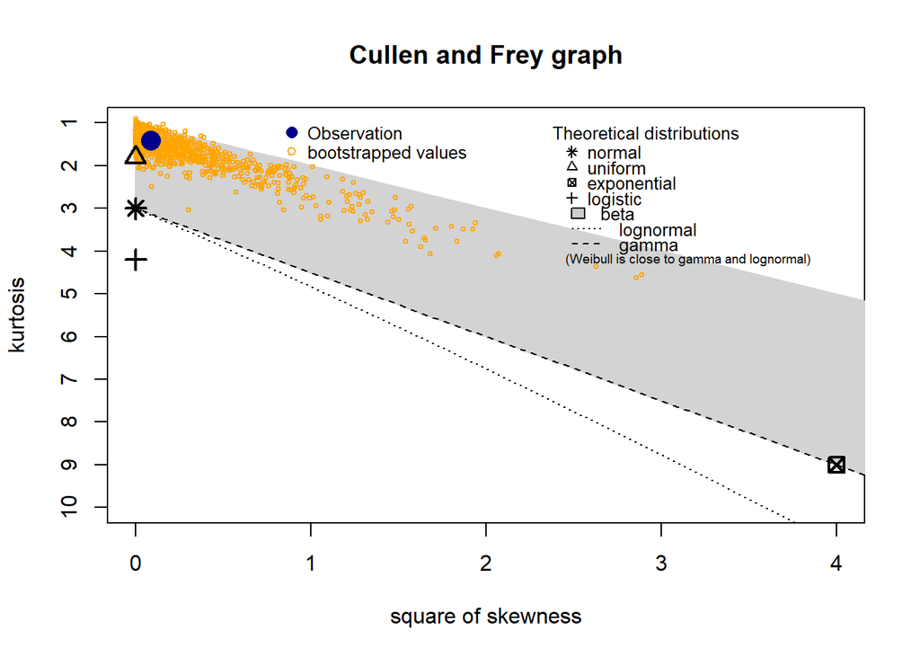

```
## summary statistics
## ------
## min:  0.0007979109   max:  0.9997544
## median:  0.6949201
## mean:  0.5751256
## estimated sd:  0.3863477
## estimated skewness:  -0.2953997
## estimated kurtosis:  1.414034
```

```r
CGrem <- subset(dfREM, Species == "Chaetomium_globosum")
descdist(CGrem$Abundance, boot = 1000)
```

```r
CGrem.mod <- lm(logistic(Abundance) ~ success, data = CGrem)
Anova(CGrem.mod, type = "II")
```

```
## Anova Table (Type II tests)
##
## Response: logistic(Abundance)
##            Sum Sq Df F value  Pr(>F)
## success    56.252  1  5.5052 0.03061 *
## Residuals 183.925 18
## ---
## Signif. codes:  0 '***' 0.001 '**' 0.01 '*' 0.05 '.' 0.1 ' ' 1
```

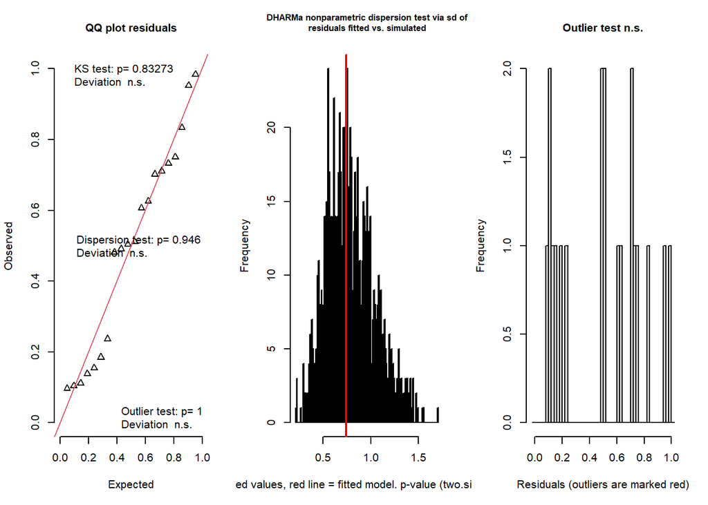

```
## $uniformity
##
##  One-sample Kolmogorov-Smirnov test
##
## data:  simulationOutput$scaledResiduals
## D = 0.132, p-value = 0.8327
## alternative hypothesis: two-sided
##
##
## $dispersion
##
##  DHARMa nonparametric dispersion test via sd of residuals fitted vs.
##  simulated
##
## data:  simulationOutput
## dispersion = 0.94547, p-value = 0.946
## alternative hypothesis: two.sided
##
##
## $outliers
##
##  DHARMa outlier test based on exact binomial test with approximate
##  expectations
##
## data:  simulationOutput
## outliers at both margin(s) = 0, observations = 20, p-value = 1
## alternative hypothesis: true probability of success is not equal to 0.001998002
## 95 percent confidence interval:
##  0.0000000 0.1684335
## sample estimates:
## frequency of outliers (expected: 0.001998001998002 )
##                                                    0
```

```
## $uniformity
##
##  One-sample Kolmogorov-Smirnov test
##
## data:  simulationOutput$scaledResiduals
## D = 0.132, p-value = 0.8327
## alternative hypothesis: two-sided
##
##
## $dispersion
##
##  DHARMa nonparametric dispersion test via sd of residuals fitted vs.
##  simulated
##
## data:  simulationOutput
## dispersion = 0.94547, p-value = 0.946
## alternative hypothesis: two.sided
##
##
## $outliers
##
##  DHARMa outlier test based on exact binomial test with approximate
##  expectations
##
## data:  simulationOutput
## outliers at both margin(s) = 0, observations = 20, p-value = 1
## alternative hypothesis: true probability of success is not equal to 0.001998002
## 95 percent confidence interval:
##  0.0000000 0.1684335
## sample estimates:
## frequency of outliers (expected: 0.001998001998002 )
##                                                    0
```

```r
res_CGrem.mod <- simulateResiduals(CGrem.mod, n = 1000)
testResiduals(res_CGrem.mod)
```

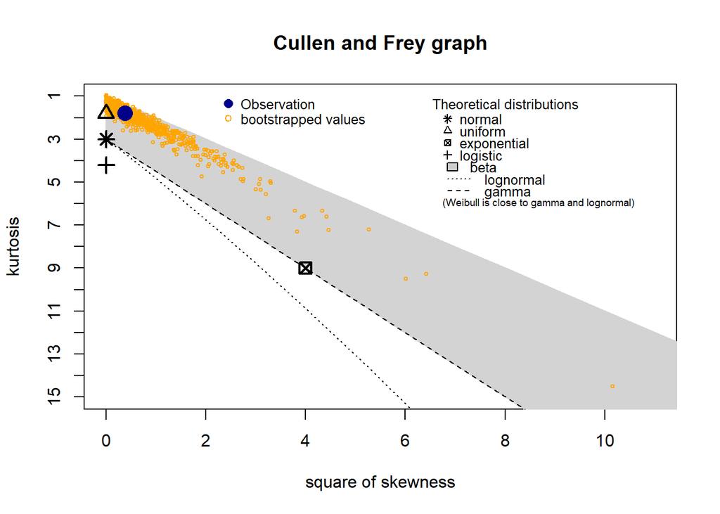

```
## summary statistics
## ------
## min:  0.0001473839   max:  0.9401502
## median:  0.1719765
## mean:  0.307603
## estimated sd:  0.3306086
## estimated skewness:  0.6144493
## estimated kurtosis:  1.77946
```

```r
RSrem <- subset(dfREM, Species == "Raffaelea_sulphurea")
descdist(RSrem$Abundance, boot = 1000)
```

```r
RSrem.mod <- lm(logistic(Abundance) ~ success, data = RSrem)
Anova(RSrem.mod, type = "II")
```

```
## Anova Table (Type II tests)
##
## Response: logistic(Abundance)
##           Sum Sq Df F value Pr(>F)
## success   11.281  1  2.1023 0.1643
## Residuals 96.585 18
```

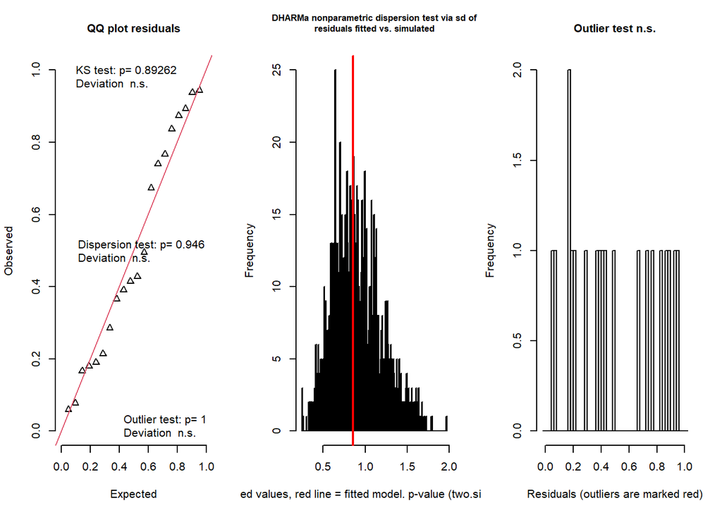

```
## $uniformity
##
##  One-sample Kolmogorov-Smirnov test
##
## data:  simulationOutput$scaledResiduals
## D = 0.122, p-value = 0.8926
## alternative hypothesis: two-sided
##
##
## $dispersion
##
##  DHARMa nonparametric dispersion test via sd of residuals fitted vs.
##  simulated
##
## data:  simulationOutput
## dispersion = 0.94547, p-value = 0.946
## alternative hypothesis: two.sided
##
##
## $outliers
##
##  DHARMa outlier test based on exact binomial test with approximate
##  expectations
##
## data:  simulationOutput
## outliers at both margin(s) = 0, observations = 20, p-value = 1
## alternative hypothesis: true probability of success is not equal to 0.001998002
## 95 percent confidence interval:
##  0.0000000 0.1684335
## sample estimates:
## frequency of outliers (expected: 0.001998001998002 )
##                                                    0
```

```
## $uniformity
##
##  One-sample Kolmogorov-Smirnov test
##
## data:  simulationOutput$scaledResiduals
## D = 0.122, p-value = 0.8926
## alternative hypothesis: two-sided
##
##
## $dispersion
##
##  DHARMa nonparametric dispersion test via sd of residuals fitted vs.
##  simulated
##
## data:  simulationOutput
## dispersion = 0.94547, p-value = 0.946
## alternative hypothesis: two.sided
##
##
## $outliers
##
##  DHARMa outlier test based on exact binomial test with approximate
##  expectations
##
## data:  simulationOutput
## outliers at both margin(s) = 0, observations = 20, p-value = 1
## alternative hypothesis: true probability of success is not equal to 0.001998002
## 95 percent confidence interval:
##  0.0000000 0.1684335
## sample estimates:
## frequency of outliers (expected: 0.001998001998002 )
##                                                    0
```

```r
res_RSrem.mod <- simulateResiduals(RSrem.mod, n = 1000)
testResiduals(res_RSrem.mod)
```

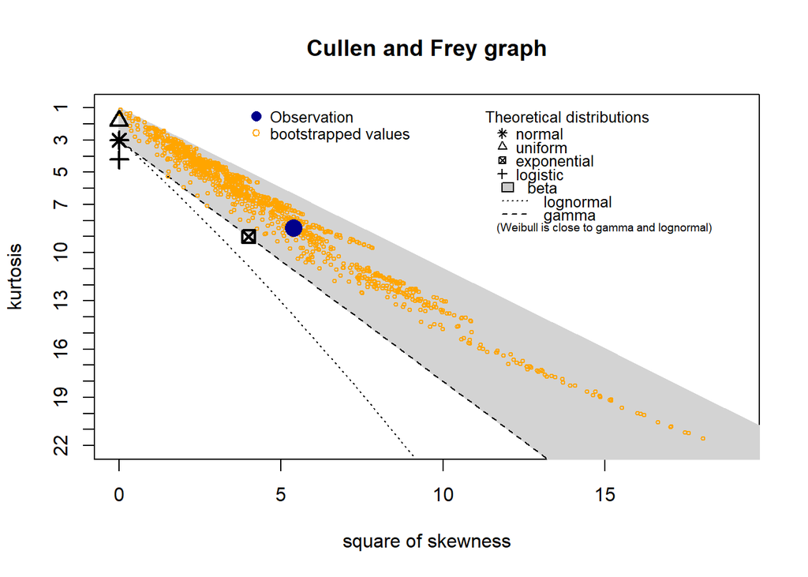

```
## summary statistics
## ------
## min:  9.825596e-05   max:  0.2323918
## median:  0.01338467
## mean:  0.03755341
## estimated sd:  0.05985818
## estimated skewness:  2.321288
## estimated kurtosis:  8.455446
```

```r
RCrem <- subset(dfREM, Species == "Raffaelea_canadensis")
descdist(RCrem$Abundance, boot = 1000)
```

```r
RCrem.mod <- lm(logistic(Abundance) ~ success, data = RCrem)
Anova(RCrem.mod, type = "II")
```

```
## Anova Table (Type II tests)
##
## Response: logistic(Abundance)
##            Sum Sq Df F value Pr(>F)
## success    2.7337  1  2.8548 0.1083
## Residuals 17.2368 18
```

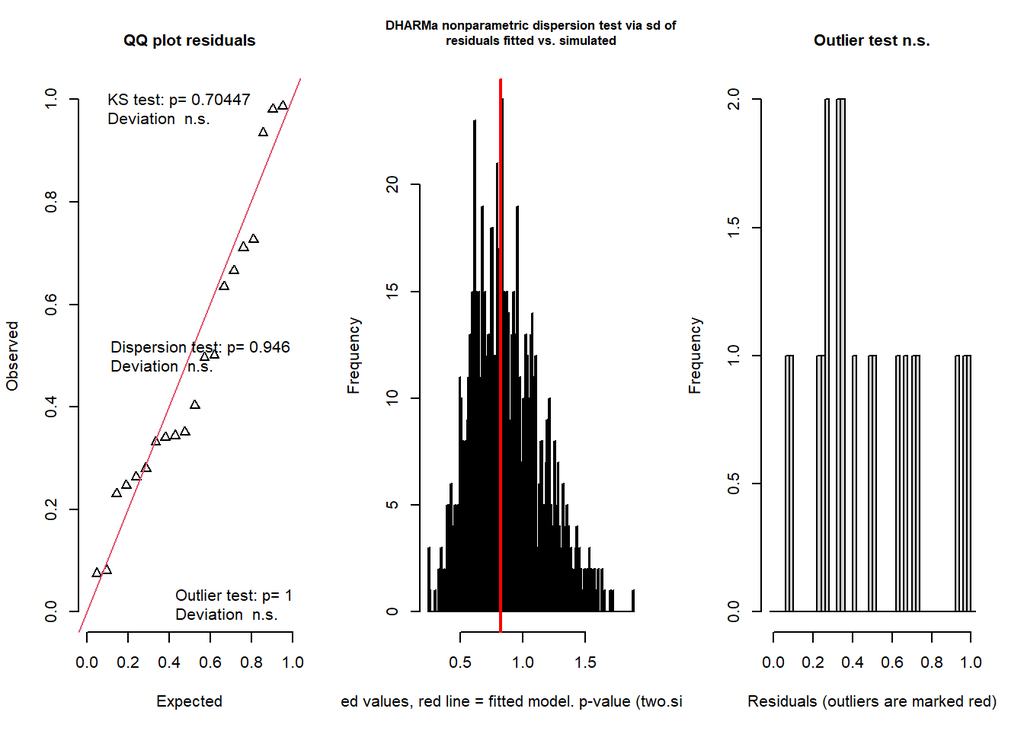

```
## $uniformity
##
##  One-sample Kolmogorov-Smirnov test
##
## data:  simulationOutput$scaledResiduals
## D = 0.15, p-value = 0.7045
## alternative hypothesis: two-sided
##
##
## $dispersion
##
##  DHARMa nonparametric dispersion test via sd of residuals fitted vs.
##  simulated
##
## data:  simulationOutput
## dispersion = 0.94547, p-value = 0.946
## alternative hypothesis: two.sided
##
##
## $outliers
##
##  DHARMa outlier test based on exact binomial test with approximate
##  expectations
##
## data:  simulationOutput
## outliers at both margin(s) = 0, observations = 20, p-value = 1
## alternative hypothesis: true probability of success is not equal to 0.001998002
## 95 percent confidence interval:
##  0.0000000 0.1684335
## sample estimates:
## frequency of outliers (expected: 0.001998001998002 )
##                                                    0
```

```
## $uniformity
##
##  One-sample Kolmogorov-Smirnov test
##
## data:  simulationOutput$scaledResiduals
## D = 0.15, p-value = 0.7045
## alternative hypothesis: two-sided
##
##
## $dispersion
##
##  DHARMa nonparametric dispersion test via sd of residuals fitted vs.
##  simulated
##
## data:  simulationOutput
## dispersion = 0.94547, p-value = 0.946
## alternative hypothesis: two.sided
##
##
## $outliers
##
##  DHARMa outlier test based on exact binomial test with approximate
##  expectations
##
## data:  simulationOutput
## outliers at both margin(s) = 0, observations = 20, p-value = 1
## alternative hypothesis: true probability of success is not equal to 0.001998002
## 95 percent confidence interval:
##  0.0000000 0.1684335
## sample estimates:
## frequency of outliers (expected: 0.001998001998002 )
##                                                    0
```

```r
res_RCrem.mod <- simulateResiduals(RCrem.mod, n = 1000)
testResiduals(res_RCrem.mod)
```

# **References**

Davis NM, Proctor DiM, Holmes SP, Relman DA, Callahan BJ. 2018. Simple statistical identification and removal of contaminant sequences in marker-gene and metagenomics data. Microbiome. 6(1). doi:10.1186/S40168-018-0605-2.

Delignette-Muller ML, Dutang C. 2015. fitdistrplus: An R package for fitting distributions. J Stat Softw. 64(4):1–34. doi:10.18637/jss.v064.i04.

Dimitris Rizopoulos (2022). GLMMadaptive: Generalized Linear Mixed Models using Adaptive Gaussian Quadrature. R package version 0.8-5. https://CRAN.R-project.org/package=GLMMadaptive

Douglas Bates, Martin Maechler, Ben Bolker, Steve Walker (2015). Fitting Linear Mixed-Effects Models Using lme4. Journal of Statistical Software, 67(1), 1-48. doi:10.18637/jss.v067.i01.

John Fox and Sanford Weisberg (2019). An {R} Companion to Applied Regression, Third Edition. Thousand Oaks CA: Sage. URL: https://socialsciences.mcmaster.ca/jfox/Books/Companion/

Gavin L. Simpson (2022). permute: Functions for Generating Restricted Permutations of Data. R package version 0.9-7. https://CRAN.R-project.org/package=permute

Hartig F. 2021. DHARMa: Residual Diagnostics for Hierarchical (Multi-Level / Mixed) Regression Models. https://cran.r-project.org/package=DHARMa.

Højsgaard, Søren and Halekoh, Ulrich (2022). doBy: Groupwise Statistics, LSmeans, Linear Estimates, Utilities. R package version 4.6.12. https://CRAN.R-project.org/package=doBy

Kassambara, Alboukadel (2020). ggpubr: ‘ggplot2’ Based Publication Ready Plots. R package version 0.4.0. https://CRAN.R-project.org/package=ggpubr

Kuznetsova A, Brockhoff PB, Christensen RHB (2017). “lmerTest Package: Tests in Linear Mixed Effects Models.” *Journal of Statistical Software*, *82*(13), 1-26. doi: 10.18637/jss.v082.i13 (URL: https://doi.org/10.18637/jss.v082.i13).

Lahti, Leo et al. microbiome R package. URL: http://microbiome.github.io

Lüdecke D (2018). “ggeffects: Tidy Data Frames of Marginal Effects from Regression Models.” *Journal of Open Source Software*, *3*(26), 772. doi: 10.21105/joss.00772 (URL: https://doi.org/10.21105/joss.00772).

Lüdecke D (2021). *sjPlot: Data Visualization for Statistics in Social Science*. R package version 2.8.10, <URL: https://CRAN.R-project.org/package=sjPlot>.

Lüdecke D, Ben-Shachar MS, Patil I, Waggoner P, Makowski D. (2021) performance: An R Package for Assessment, Comparison and Testing of Statistical Models. Journal of Open Source Software, 6(60), 3139. doi:10.21105/joss.03139.

Lüdecke et al., (2021). see: An R Package for Visualizing Statistical Models. Journal of Open Source Software, 6(64), 3393. https://doi.org/10.21105/joss.03393

Mangiafico S. 2021. rcompanion: Functions to Support Extension Education Program Evaluation. https://cran.r-project.org/package=rcompanion.

Martinez Arbizu, Pedro (2017). pairwiseAdonis: Pairwise Multilevel Comparison using Adonis. R package version 0.4.

McMurdie PJ, Holmes S. 2013. Phyloseq: An R Package for Reproducible Interactive Analysis and Graphics of Microbiome Census Data. PLoS One. 8(4):e61217. doi:10.1371/journal.pone.0061217.

Mollie E. Brooks, Kasper Kristensen, Koen J. van Benthem, Arni Magnusson, Casper W. Berg, Anders Nielsen, Hans J. Skaug, Martin Maechler and Benjamin M. Bolker (2017). glmmTMB Balances Speed and Flexibility Among Packages for Zero-inflated Generalized Linear Mixed Modeling. The R Journal, 9(2), 378-400.

Oksanen J, Blanchet FG, Friendly M, Kindt R, Legendre P, McGlinn D, Minchin PR, O’Hara RB, Simpson GL, Solymos P, et al. 2020a. vegan: Community Ecology Package. https://cran.r-project.org/package=vegan.

Pedersen, Thomas Lin (2020). patchwork: The Composer of Plots. R package version 1.1.1. https://CRAN.R-project.org/package=patchwork

R Core Team. 2021. R: A language and environment for statistical computing. https://www.r-project.org/.

Russell V. Lenth (2022). emmeans: Estimated Marginal Means, aka Least-Squares Means. R package version 1.7.2. https://CRAN.R-project.org/package=emmeans

Sarkar, Deepayan (2008) Lattice: Multivariate Data Visualization with R. Springer, New York. ISBN 978-0-387-75968-5

Shetty, Sudarshan and Lahti, Leo (2021). microbiomeutilities: microbiomeutilities: Utilities for Microbiome Analytics. R package version 1.00.16.

Slowikowski, Kamil (2021). ggrepel: Automatically Position Non-Overlapping Text Labels with ‘ggplot2’. R package version 0.9.1. https://CRAN.R-project.org/package=ggrepel

Wickham H. 2016. ggplot2: Elegant Graphics for Data Analysis. New York: Springer-Verlag New York.

Wickham et al., (2019). Welcome to the tidyverse. Journal of Open Source Software, 4(43), 1686, https://doi.org/10.21105/joss.01686

Wickham H, Seidel D. 2020. scales: Scale Functions for Visualization. https://cran.r-project.org/package=scales.

Wickham H, François R, Henry L, Müller K. 2021. dplyr: A Grammar of Data Manipulation. https://cran.r-project.org/package=dplyr.

Hadley Wickham (2021). forcats: Tools for Working with Categorical Variables (Factors). R package version 0.5.1. https://CRAN.R-project.org/package=forcats

Wilke, Claus O. (2020). cowplot: Streamlined Plot Theme and Plot Annotations for ‘ggplot2’. R package version 1.1.1. https://CRAN.R-project.org/package=cowplot

Yihui Xie (2021). knitr: A General-Purpose Package for Dynamic Report Generation in R. R package version 1.37.